# PWB CFA TR Youth

# Deal with NA doing principle componant analysis.

```r
princomp(na.omit(PWB), cor = TRUE)
```

```
## Call:
## princomp(x = na.omit(PWB), cor = TRUE)
##
## Standard deviations:
##    Comp.1    Comp.2    Comp.3    Comp.4    Comp.5    Comp.6    Comp.7
## 1.8271781 1.2556471 0.9950615 0.8300724 0.8048028 0.7172643 0.6810303
##    Comp.8    Comp.9
## 0.6407490 0.6075076
##
##  9  variables and  944 observations.
```

```r
parallel2<-princomp(na.omit(PWB), cor = TRUE)
summary(parallel2)
```

```
## Importance of components:
##                           Comp.1    Comp.2    Comp.3     Comp.4    Comp.5
## Standard deviation     1.8271781 1.2556471 0.9950615 0.83007244 0.8048028
## Proportion of Variance 0.3709533 0.1751833 0.1100164 0.07655781 0.0719675
## Cumulative Proportion  0.3709533 0.5461366 0.6561530 0.73271081 0.8046783
##                            Comp.6     Comp.7    Comp.8     Comp.9
## Standard deviation     0.71726434 0.68103033 0.6407490 0.60750759
## Proportion of Variance 0.05716313 0.05153359 0.0456177 0.04100727
## Cumulative Proportion  0.86184143 0.91337502 0.9589927 1.00000000
```

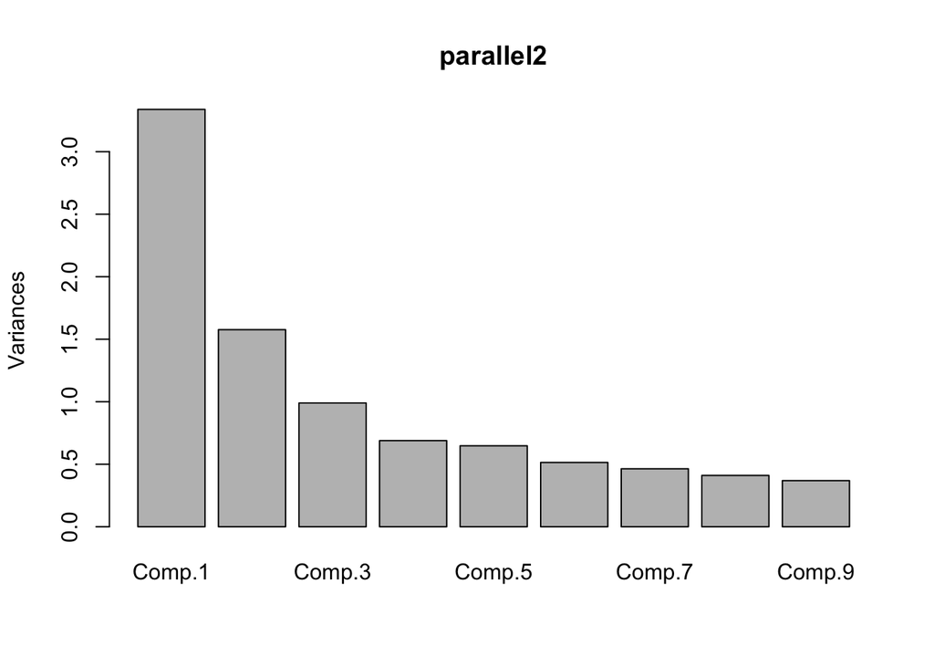

```r
plot(parallel2)##results show at least two factors
```

#simple structure

```r
twofactor<-fa(PWB, nfactors=2, rotate="oblimin", fm="ml")
twofactor
```

```
## Factor Analysis using method =  ml
## Call: fa(r = PWB, nfactors = 2, rotate = "oblimin", fm = "ml")
## Standardized loadings (pattern matrix) based upon correlation matrix
##     ML1   ML2   h2   u2 com
## 1  0.67 -0.15 0.44 0.56 1.1
## 2  0.51  0.06 0.27 0.73 1.0
## 3  0.77 -0.02 0.59 0.41 1.0
## 4  0.51  0.26 0.38 0.62 1.5
## 5 -0.78  0.00 0.60 0.40 1.0
## 6  0.43  0.30 0.32 0.68 1.8
## 7 -0.03  0.87 0.75 0.25 1.0
## 8  0.04  0.59 0.36 0.64 1.0
## 9  0.46  0.02 0.21 0.79 1.0
##
##                        ML1  ML2
## SS loadings           2.60 1.32
## Proportion Var        0.29 0.15
## Cumulative Var        0.29 0.44
## Proportion Explained  0.66 0.34
## Cumulative Proportion 0.66 1.00
##
##  With factor correlations of
##      ML1  ML2
## ML1 1.00 0.19
## ML2 0.19 1.00
##
## Mean item complexity =  1.2
## Test of the hypothesis that 2 factors are sufficient.
##
## The degrees of freedom for the null model are  36  and the objective function was  2.48 with Chi Square of  2325.18
## The degrees of freedom for the model are 19  and the objective function was  0.21
##
## The root mean square of the residuals (RMSR) is  0.05
## The df corrected root mean square of the residuals is  0.07
##
## The harmonic number of observations is  944 with the empirical chi square  176.93  with prob <  1.2e-27
## The total number of observations was  944  with MLE Chi Square =  195.13  with prob <  3.2e-31
##
## Tucker Lewis Index of factoring reliability =  0.854
## RMSEA index =  0.099  and the 90 % confidence intervals are  0.087 0.112
## BIC =  64.98
## Fit based upon off diagonal values = 0.97
## Measures of factor score adequacy
##                                                 ML1  ML2
## Correlation of scores with factors             0.91 0.89
## Multiple R square of scores with factors       0.84 0.79
## Minimum correlation of possible factor scores  0.67 0.59
```

```r
1-((twofactor$STATISTIC - twofactor$dof)/(twofactor$null.chisq- twofactor$null.dof))
```

```
## [1] 0.9230604
```

```r
fa2latex(fa(PWB,2,rotate="oblimin", fm="ml"), heading="Table 1. Factor Loadings for Exploratory Factor Analysis PWB")
```

```
## % Called in the psych package  fa2latex % Called in the psych package  fa(PWB, 2, rotate = "oblimin", fm = "ml") % Called in the psych package  Table 1. Factor Loadings for Exploratory Factor Analysis PWB
## \begin{table}[htpb]\caption{fa2latex}
## \begin{center}
## \begin{scriptsize}
## \begin{tabular} {l r r r r r }
##  \multicolumn{ 5 }{l}{ Table 1. Factor Loadings for Exploratory Factor Analysis PWB } \cr
##  \hline Variable  &   ML1  &  ML2  &  h2  &  u2  &  com \cr
##   \hline
## 1   &  \bf{ 0.67}  &  -0.15  &  0.44  &  0.56  &  1.10 \cr
##  2   &  \bf{ 0.51}  &   0.06  &  0.27  &  0.73  &  1.03 \cr
##  3   &  \bf{ 0.77}  &  -0.02  &  0.59  &  0.41  &  1.00 \cr
##  4   &  \bf{ 0.51}  &   0.26  &  0.38  &  0.62  &  1.49 \cr
##  5   &  \bf{-0.78}  &   0.00  &  0.60  &  0.40  &  1.00 \cr
##  6   &  \bf{ 0.43}  &   0.30  &  0.32  &  0.68  &  1.79 \cr
##  7   &  -0.03  &  \bf{ 0.87}  &  0.75  &  0.25  &  1.00 \cr
##  8   &   0.04  &  \bf{ 0.59}  &  0.36  &  0.64  &  1.01 \cr
##  9   &  \bf{ 0.46}  &   0.02  &  0.21  &  0.79  &  1.00 \cr
## \hline \cr SS loadings & 2.6 &  1.32 &  \cr
## \cr
##             \hline \cr
## ML1   & 1.00 & 0.19 \cr
##  ML2   & 0.19 & 1.00 \cr
##  \hline
## \end{tabular}
## \end{scriptsize}
## \end{center}
## \label{default}
## \end{table}
```

```r
threefactor<-fa(PWB, nfactors=3, rotate="oblimin", fm="ml")
threefactor
```

```
## Factor Analysis using method =  ml
## Call: fa(r = PWB, nfactors = 3, rotate = "oblimin", fm = "ml")
## Standardized loadings (pattern matrix) based upon correlation matrix
##     ML1   ML2   ML3   h2   u2 com
## 1  0.54 -0.17  0.23 0.44 0.56 1.6
## 2  0.13  0.12  0.58 0.44 0.56 1.2
## 3  0.70 -0.07  0.15 0.59 0.41 1.1
## 4  0.27  0.29  0.38 0.42 0.58 2.7
## 5 -0.72  0.05 -0.15 0.61 0.39 1.1
## 6  0.69  0.23 -0.28 0.52 0.48 1.6
## 7 -0.04  0.84  0.05 0.70 0.30 1.0
## 8  0.03  0.61  0.02 0.38 0.62 1.0
## 9  0.13  0.07  0.48 0.32 0.68 1.2
##
##                        ML1  ML2  ML3
## SS loadings           2.07 1.29 1.06
## Proportion Var        0.23 0.14 0.12
## Cumulative Var        0.23 0.37 0.49
## Proportion Explained  0.47 0.29 0.24
## Cumulative Proportion 0.47 0.76 1.00
##
##  With factor correlations of
##      ML1   ML2   ML3
## ML1 1.00  0.25  0.44
## ML2 0.25  1.00 -0.02
## ML3 0.44 -0.02  1.00
##
## Mean item complexity =  1.4
## Test of the hypothesis that 3 factors are sufficient.
##
## The degrees of freedom for the null model are  36  and the objective function was  2.48 with Chi Square of  2325.18
## The degrees of freedom for the model are 12  and the objective function was  0.07
##
## The root mean square of the residuals (RMSR) is  0.02
## The df corrected root mean square of the residuals is  0.04
##
## The harmonic number of observations is  944 with the empirical chi square  40.04  with prob <  7.1e-05
## The total number of observations was  944  with MLE Chi Square =  69.45  with prob <  4.1e-10
##
## Tucker Lewis Index of factoring reliability =  0.925
## RMSEA index =  0.072  and the 90 % confidence intervals are  0.056 0.088
## BIC =  -12.76
## Fit based upon off diagonal values = 0.99
## Measures of factor score adequacy
##                                                 ML1  ML2  ML3
## Correlation of scores with factors             0.91 0.88 0.80
## Multiple R square of scores with factors       0.82 0.77 0.64
## Minimum correlation of possible factor scores  0.64 0.53 0.28
```

```r
1-((threefactor$STATISTIC - threefactor$dof)/(threefactor$null.chisq- threefactor$null.dof))
```

```
## [1] 0.9749055
```

```r
fa2latex(fa(PWB,3,rotate="oblimin", fm="ml"), heading="Table 2. Factor Loadings for Exploratory Factor Analysis PWB")
```

```
## % Called in the psych package  fa2latex % Called in the psych package  fa(PWB, 3, rotate = "oblimin", fm = "ml") % Called in the psych package  Table 2. Factor Loadings for Exploratory Factor Analysis PWB
## \begin{table}[htpb]\caption{fa2latex}
## \begin{center}
## \begin{scriptsize}
## \begin{tabular} {l r r r r r r }
##  \multicolumn{ 6 }{l}{ Table 2. Factor Loadings for Exploratory Factor Analysis PWB } \cr
##  \hline Variable  &   ML1  &  ML2  &  ML3  &  h2  &  u2  &  com \cr
##   \hline
## 1   &  \bf{ 0.54}  &  -0.17  &   0.23  &  0.44  &  0.56  &  1.58 \cr
##  2   &   0.13  &   0.12  &  \bf{ 0.58}  &  0.44  &  0.56  &  1.18 \cr
##  3   &  \bf{ 0.70}  &  -0.07  &   0.15  &  0.59  &  0.41  &  1.11 \cr
##  4   &   0.27  &   0.29  &  \bf{ 0.38}  &  0.42  &  0.58  &  2.72 \cr
##  5   &  \bf{-0.72}  &   0.05  &  -0.15  &  0.61  &  0.39  &  1.09 \cr
##  6   &  \bf{ 0.69}  &   0.23  &  -0.28  &  0.52  &  0.48  &  1.57 \cr
##  7   &  -0.04  &  \bf{ 0.84}  &   0.05  &  0.70  &  0.30  &  1.01 \cr
##  8   &   0.03  &  \bf{ 0.61}  &   0.02  &  0.38  &  0.62  &  1.01 \cr
##  9   &   0.13  &   0.07  &  \bf{ 0.48}  &  0.32  &  0.68  &  1.19 \cr
## \hline \cr SS loadings & 2.07 &  1.29 &  1.06 &  \cr
## \cr
##             \hline \cr
## ML1   &  1.00 &  0.25 &  0.44 \cr
##  ML2   &  0.25 &  1.00 & -0.02 \cr
##  ML3   &  0.44 & -0.02 &  1.00 \cr
##  \hline
## \end{tabular}
## \end{scriptsize}
## \end{center}
## \label{default}
## \end{table}
```

```r
fourfactor<-fa(PWB, nfactors=4, rotate="oblimin", fm="ml")
fourfactor
```

```
## Factor Analysis using method =  ml
## Call: fa(r = PWB, nfactors = 4, rotate = "oblimin", fm = "ml")
## Standardized loadings (pattern matrix) based upon correlation matrix
##     ML1   ML2   ML4   ML3   h2   u2 com
## 1  0.13 -0.23  0.52  0.30 0.54 0.46 2.2
## 2 -0.01  0.09  0.75 -0.06 0.56 0.44 1.0
## 3  0.84 -0.05 -0.05  0.04 0.68 0.32 1.0
## 4  0.50  0.31  0.15 -0.15 0.45 0.55 2.1
## 5 -0.60  0.04 -0.13 -0.16 0.58 0.42 1.2
## 6  0.11  0.19  0.00  0.70 0.66 0.34 1.2
## 7 -0.02  0.79  0.01  0.08 0.65 0.35 1.0
## 8  0.01  0.60  0.01  0.09 0.40 0.60 1.0
## 9  0.31  0.07  0.32 -0.17 0.29 0.71 2.6
##
##                        ML1  ML2  ML4  ML3
## SS loadings           1.68 1.22 1.15 0.75
## Proportion Var        0.19 0.14 0.13 0.08
## Cumulative Var        0.19 0.32 0.45 0.53
## Proportion Explained  0.35 0.25 0.24 0.16
## Cumulative Proportion 0.35 0.60 0.84 1.00
##
##  With factor correlations of
##      ML1  ML2  ML4  ML3
## ML1 1.00 0.14 0.63 0.48
## ML2 0.14 1.00 0.12 0.20
## ML4 0.63 0.12 1.00 0.19
## ML3 0.48 0.20 0.19 1.00
##
## Mean item complexity =  1.5
## Test of the hypothesis that 4 factors are sufficient.
##
## The degrees of freedom for the null model are  36  and the objective function was  2.48 with Chi Square of  2325.18
## The degrees of freedom for the model are 6  and the objective function was  0.01
##
## The root mean square of the residuals (RMSR) is  0.01
## The df corrected root mean square of the residuals is  0.02
##
## The harmonic number of observations is  944 with the empirical chi square  2.69  with prob <  0.85
## The total number of observations was  944  with MLE Chi Square =  4.93  with prob <  0.55
##
## Tucker Lewis Index of factoring reliability =  1.003
## RMSEA index =  0  and the 90 % confidence intervals are  NA 0.038
## BIC =  -36.17
## Fit based upon off diagonal values = 1
## Measures of factor score adequacy
##                                                 ML1  ML2  ML4  ML3
## Correlation of scores with factors             0.91 0.86 0.85 0.82
## Multiple R square of scores with factors       0.83 0.74 0.73 0.68
## Minimum correlation of possible factor scores  0.65 0.48 0.45 0.35
```

```r
1-((fourfactor$STATISTIC - fourfactor$dof)/(fourfactor$null.chisq- fourfactor$null.dof))
```

```
## [1] 1.000468
```

```r
fa2latex(fa(PWB,4,rotate="oblimin", fm="ml"), heading="Table 3. Factor Loadings for Exploratory Factor Analysis PWB")
```

```
## % Called in the psych package  fa2latex % Called in the psych package  fa(PWB, 4, rotate = "oblimin", fm = "ml") % Called in the psych package  Table 3. Factor Loadings for Exploratory Factor Analysis PWB
## \begin{table}[htpb]\caption{fa2latex}
## \begin{center}
## \begin{scriptsize}
## \begin{tabular} {l r r r r r r r }
##  \multicolumn{ 7 }{l}{ Table 3. Factor Loadings for Exploratory Factor Analysis PWB } \cr
##  \hline Variable  &   ML1  &  ML2  &  ML4  &  ML3  &  h2  &  u2  &  com \cr
##   \hline
## 1   &   0.13  &  -0.23  &  \bf{ 0.52}  &   0.30  &  0.54  &  0.46  &  2.19 \cr
##  2   &  -0.01  &   0.09  &  \bf{ 0.75}  &  -0.06  &  0.56  &  0.44  &  1.04 \cr
##  3   &  \bf{ 0.84}  &  -0.05  &  -0.05  &   0.04  &  0.68  &  0.32  &  1.02 \cr
##  4   &  \bf{ 0.50}  &  \bf{ 0.31}  &   0.15  &  -0.15  &  0.45  &  0.55  &  2.08 \cr
##  5   &  \bf{-0.60}  &   0.04  &  -0.13  &  -0.16  &  0.58  &  0.42  &  1.24 \cr
##  6   &   0.11  &   0.19  &   0.00  &  \bf{ 0.70}  &  0.66  &  0.34  &  1.20 \cr
##  7   &  -0.02  &  \bf{ 0.79}  &   0.01  &   0.08  &  0.65  &  0.35  &  1.02 \cr
##  8   &   0.01  &  \bf{ 0.60}  &   0.01  &   0.09  &  0.40  &  0.60  &  1.05 \cr
##  9   &  \bf{ 0.31}  &   0.07  &  \bf{ 0.32}  &  -0.17  &  0.29  &  0.71  &  2.60 \cr
## \hline \cr SS loadings & 1.68 &  1.22 &  1.15 &  0.75 &  \cr
## \cr
##             \hline \cr
## ML1   & 1.00 & 0.14 & 0.63 & 0.48 \cr
##  ML2   & 0.14 & 1.00 & 0.12 & 0.20 \cr
##  ML4   & 0.63 & 0.12 & 1.00 & 0.19 \cr
##  ML3   & 0.48 & 0.20 & 0.19 & 1.00 \cr
##  \hline
## \end{tabular}
## \end{scriptsize}
## \end{center}
## \label{default}
## \end{table}
```

# question 1,3,5,6,9 seems to be one factor and all talk about plans or lack of plans

```r
 PWBWO15<-select(PWB,  1,3,5,6,9)
 PWBWO15<-tbl_df(PWBWO15)
 PWBWO15
```

```
## Source: local data frame [944 x 5]
##
##        1     3     5     6     9
##    (dbl) (dbl) (dbl) (dbl) (dbl)
## 1      4     5     5     4     1
## 2      2     4     6     1     3
## 3      2     3     5     4     2
## 4      5     5     3     5     6
## 5      3     3     4     4     3
## 6      1     2     4     4     2
## 7      3     3     3     3     4
## 8      1     1     6     6     1
## 9      5     5     1     5     5
## 10     2     2     5     5     2
## ..   ...   ...   ...   ...   ...
```

```r
twofactorWO15<-fa(PWBWO15, nfactors=1, rotate="oblimin", fm="ml")
twofactorWO15
```

```
## Factor Analysis using method =  ml
## Call: fa(r = PWBWO15, nfactors = 1, rotate = "oblimin", fm = "ml")
## Standardized loadings (pattern matrix) based upon correlation matrix
##     ML1   h2   u2 com
## 1  0.61 0.37 0.63   1
## 3  0.77 0.59 0.41   1
## 5 -0.81 0.65 0.35   1
## 6  0.51 0.26 0.74   1
## 9  0.42 0.18 0.82   1
##
##                 ML1
## SS loadings    2.05
## Proportion Var 0.41
##
## Mean item complexity =  1
## Test of the hypothesis that 1 factor is sufficient.
##
## The degrees of freedom for the null model are  10  and the objective function was  1.23 with Chi Square of  1158.85
## The degrees of freedom for the model are 5  and the objective function was  0.03
##
## The root mean square of the residuals (RMSR) is  0.04
## The df corrected root mean square of the residuals is  0.05
##
## The harmonic number of observations is  944 with the empirical chi square  26.66  with prob <  6.6e-05
## The total number of observations was  944  with MLE Chi Square =  23.97  with prob <  0.00022
##
## Tucker Lewis Index of factoring reliability =  0.967
## RMSEA index =  0.064  and the 90 % confidence intervals are  0.039 0.09
## BIC =  -10.28
## Fit based upon off diagonal values = 0.99
## Measures of factor score adequacy
##                                                 ML1
## Correlation of scores with factors             0.90
## Multiple R square of scores with factors       0.82
## Minimum correlation of possible factor scores  0.63
```

```r
fa2latex(fa(PWBWO15,3,rotate="oblimin", fm="ml"), heading="Table 4. Factor Loadings for Exploratory Factor Analysis PWB")
```

```
## % Called in the psych package  fa2latex % Called in the psych package  fa(PWBWO15, 3, rotate = "oblimin", fm = "ml") % Called in the psych package  Table 4. Factor Loadings for Exploratory Factor Analysis PWB
## \begin{table}[htpb]\caption{fa2latex}
## \begin{center}
## \begin{scriptsize}
## \begin{tabular} {l r r r r r r }
##  \multicolumn{ 6 }{l}{ Table 4. Factor Loadings for Exploratory Factor Analysis PWB } \cr
##  \hline Variable  &   ML1  &  ML2  &  ML3  &  h2  &  u2  &  com \cr
##   \hline
## 1   &  -0.03  &  \bf{ 0.36}  &  \bf{ 0.37}  &  0.40  &  0.60  &  2.01 \cr
##  3   &  -0.28  &  \bf{ 0.31}  &   0.27  &  0.56  &  0.44  &  2.97 \cr
##  5   &  \bf{ 0.88}  &   0.00  &   0.00  &  0.76  &  0.24  &  1.00 \cr
##  6   &  -0.04  &  \bf{ 0.64}  &  -0.06  &  0.42  &  0.58  &  1.03 \cr
##  9   &  -0.06  &  -0.08  &  \bf{ 0.57}  &  0.34  &  0.66  &  1.06 \cr
## \hline \cr SS loadings & 1.03 &  0.78 &  0.67 &  \cr
## \cr
##             \hline \cr
## ML1   &  1.00 & -0.75 & -0.72 \cr
##  ML2   & -0.75 &  1.00 &  0.40 \cr
##  ML3   & -0.72 &  0.40 &  1.00 \cr
##  \hline
## \end{tabular}
## \end{scriptsize}
## \end{center}
## \label{default}
## \end{table}
```

# CFI, should be slightly higher than the TLI

```r
1-((twofactorWO15$STATISTIC - twofactorWO15$dof)/(twofactorWO15$null.chisq- twofactorWO15$null.dof))
```

```
## [1] 0.9834837
```

# question 7,8 seems to be one factor and all talk about being active or wondering aimlessly

```r
 PWB78<-select(PWB,  7,8)
 PWB78<-tbl_df(PWB78)
 PWB78
```

```
## Source: local data frame [944 x 2]
##
##        7     8
##    (dbl) (dbl)
## 1      3     5
## 2      2     4
## 3      6     6
## 4      4     4
## 5      4     4
## 6      4     4
## 7      4     3
## 8      2     6
## 9      5     5
## 10     5     5
## ..   ...   ...
```

```r
twofactor78<-fa(PWB78, nfactors=1, rotate="oblimin", fm="ml")
twofactor78
```

```
## Factor Analysis using method =  ml
## Call: fa(r = PWB78, nfactors = 1, rotate = "oblimin", fm = "ml")
## Standardized loadings (pattern matrix) based upon correlation matrix
##    ML1  h2  u2 com
## 7 0.71 0.5 0.5   1
## 8 0.71 0.5 0.5   1
##
##                 ML1
## SS loadings    1.01
## Proportion Var 0.50
##
## Mean item complexity =  1
## Test of the hypothesis that 1 factor is sufficient.
##
## The degrees of freedom for the null model are  1  and the objective function was  0.29 with Chi Square of  277.04
## The degrees of freedom for the model are -1  and the objective function was  0
##
## The root mean square of the residuals (RMSR) is  0
## The df corrected root mean square of the residuals is  NA
##
## The harmonic number of observations is  944 with the empirical chi square  0  with prob <  NA
## The total number of observations was  944  with MLE Chi Square =  0  with prob <  NA
##
## Tucker Lewis Index of factoring reliability =  1.004
## Fit based upon off diagonal values = 1
## Measures of factor score adequacy
##                                                 ML1
## Correlation of scores with factors             0.82
## Multiple R square of scores with factors       0.67
## Minimum correlation of possible factor scores  0.34
```

```r
fa2latex(fa(PWB78,1,rotate="oblimin", fm="ml"), heading="Table 5. Factor Loadings for Exploratory Factor Analysis PWB")
```

```
## % Called in the psych package  fa2latex % Called in the psych package  fa(PWB78, 1, rotate = "oblimin", fm = "ml") % Called in the psych package  Table 5. Factor Loadings for Exploratory Factor Analysis PWB
## \begin{table}[htpb]\caption{fa2latex}
## \begin{center}
## \begin{scriptsize}
## \begin{tabular} {l r r r r }
##  \multicolumn{ 4 }{l}{ Table 5. Factor Loadings for Exploratory Factor Analysis PWB } \cr
##  \hline Variable  &   ML1  &  ML1.1  &  ML1.2  &  com \cr
##   \hline
## 7   &  \bf{0.71}  &  0.5  &  0.5  &  1 \cr
##  8   &  \bf{0.71}  &  0.5  &  0.5  &  1 \cr
## \hline \cr SS loadings & 1.01 &  \cr
##  \hline
## \end{tabular}
## \end{scriptsize}
## \end{center}
## \label{default}
## \end{table}
```

# CFI, should be slightly higher than the TLI

```r
1-((twofactor78$STATISTIC - twofactor78$dof)/(twofactor78$null.chisq- twofactor78$null.dof))
```

```
## [1] 0.9963773
```

# question 2,8 seems to be one factor

```r
 PWB29<-select(PWB, 2,8)
 PWB29<-tbl_df(PWB29)
 PWB29
```

```
## Source: local data frame [944 x 2]
##
##        2     8
##    (dbl) (dbl)
## 1      6     5
## 2      2     4
## 3      3     6
## 4      2     4
## 5      3     4
## 6      2     4
## 7      4     3
## 8      2     6
## 9      5     5
## 10     2     5
## ..   ...   ...
```

```r
twofactor29<-fa(PWB29, nfactors=1, rotate="oblimin", fm="ml")
twofactor29
```

```
## Factor Analysis using method =  ml
## Call: fa(r = PWB29, nfactors = 1, rotate = "oblimin", fm = "ml")
## Standardized loadings (pattern matrix) based upon correlation matrix
##    ML1   h2   u2 com
## 2 0.34 0.12 0.88   1
## 8 0.34 0.12 0.88   1
##
##                 ML1
## SS loadings    0.24
## Proportion Var 0.12
##
## Mean item complexity =  1
## Test of the hypothesis that 1 factor is sufficient.
##
## The degrees of freedom for the null model are  1  and the objective function was  0.01 with Chi Square of  13.32
## The degrees of freedom for the model are -1  and the objective function was  0
##
## The root mean square of the residuals (RMSR) is  0
## The df corrected root mean square of the residuals is  NA
##
## The harmonic number of observations is  944 with the empirical chi square  0  with prob <  NA
## The total number of observations was  944  with MLE Chi Square =  0  with prob <  NA
##
## Tucker Lewis Index of factoring reliability =  1.081
## Fit based upon off diagonal values = 1
## Measures of factor score adequacy
##                                                  ML1
## Correlation of scores with factors              0.46
## Multiple R square of scores with factors        0.21
## Minimum correlation of possible factor scores  -0.58
```

```r
fa2latex(fa(PWB29,1,rotate="oblimin", fm="ml"), heading="Table 6. Factor Loadings for Exploratory Factor Analysis PWB")
```

```
## % Called in the psych package  fa2latex % Called in the psych package  fa(PWB29, 1, rotate = "oblimin", fm = "ml") % Called in the psych package  Table 6. Factor Loadings for Exploratory Factor Analysis PWB
## \begin{table}[htpb]\caption{fa2latex}
## \begin{center}
## \begin{scriptsize}
## \begin{tabular} {l r r r r }
##  \multicolumn{ 4 }{l}{ Table 6. Factor Loadings for Exploratory Factor Analysis PWB } \cr
##  \hline Variable  &   ML1  &  ML1.1  &  ML1.2  &  com \cr
##   \hline
## 2   &  \bf{0.34}  &  0.12  &  0.88  &  1 \cr
##  8   &  \bf{0.34}  &  0.12  &  0.88  &  1 \cr
## \hline \cr SS loadings & 0.24 &  \cr
##  \hline
## \end{tabular}
## \end{scriptsize}
## \end{center}
## \label{default}
## \end{table}
```

# CFI, should be slightly higher than the TLI

```r
1-((twofactor29$STATISTIC - twofactor29$dof)/(twofactor29$null.chisq- twofactor29$null.dof))
```

```
## [1] 0.9187993
```

# Finding Alpha

```r
#alpha(PWB, na.rm = TRUE, check.keys=TRUE)
```

# CFA in Lavaan

```r
data <- read.csv("~/Dropbox/Git/stats/allsurveysYT1_Jan2016.csv", header=T)
data<-tbl_df(data)
PWB<-select(data, PWB_1, PWB_2, PWB_3, PWB_4, PWB_5, PWB_6,PWB_7, PWB_8, PWB_9)
PWB$PWB_1  <-  7- PWB$PWB_1
PWB$PWB_2  <-  7- PWB$PWB_2
PWB$PWB_3  <-  7- PWB$PWB_3
PWB$PWB_4  <-  7- PWB$PWB_4
PWB$PWB_9  <-  7- PWB$PWB_9
PWB<-tbl_df(PWB)
PWB
```

```
## Source: local data frame [1,288 x 9]
##
##    PWB_1 PWB_2 PWB_3 PWB_4 PWB_5 PWB_6 PWB_7 PWB_8 PWB_9
##    (dbl) (dbl) (dbl) (dbl) (int) (int) (int) (int) (dbl)
## 1      4     6     5     3     5     4     3     5     1
## 2      2     2     4     4     6     1     2     4     3
## 3      2     3     3     2     5     4     6     6     2
## 4      5     2     5     5     3     5     4     4     6
## 5      3     3     3     3     4     4     4     4     3
## 6      1     2     2     2     4     4     4     4     2
## 7      3     4     3     4     3     3     4     3     4
## 8      1     2     1     1     6     6     2     6     1
## 9      5     5     5     5     1     5     5     5     5
## 10     2     2     2     2     5     5     5     5     2
## ..   ...   ...   ...   ...   ...   ...   ...   ...   ...
```

# create plots

```r
#ggpairs(PWB, columns = 1:15, title="Big 5 Marsh" )
```

# create the models

```r
two.model= ' Factor1  =~ PWB_1 +  PWB_3  + PWB_4 + PWB_5 + PWB_6 + PWB_9
              Factor2 =~   PWB_2+ PWB_7 + PWB_8
'  #Models two factors:Positive and Negative


one.model= 'PWB =~ PWB_1 +  PWB_2  + PWB_3 + PWB_4 + PWB_5 + PWB_6 + PWB_7 + PWB_8 + PWB_9' #Models as a single purpose factor
```

Second order models

```r
second.model = '  Negative  =~  PWB_1 +  PWB_2  + PWB_3 + PWB_4 + PWB_5 + PWB_9
                Positive =~   PWB_6 + PWB_7 + PWB_8
                Purpose =~ Negative + Positive
' #Second order models as Purpose being the higher factor made up of Purpose and Positive
```

Bifactor (like model 7 in Marsh, Scalas & Nagengast, 2010)

```r
bifactor.negative.model = 'Negative =~ PWB_1 +  PWB_2  + PWB_3 + PWB_4 + PWB_5 + PWB_9
                                     PWB =~ PWB_1 +  PWB_2  + PWB_3 + PWB_4 + PWB_5 + PWB_6 + PWB_7 + PWB_8 + PWB_9
'
#Models bifactor as the negatively worded item as a factor uncorolated with the main factor


bifactor.model1 = 'PWB =~ PWB_1 +  PWB_2  + PWB_3 + PWB_4 + PWB_5 + PWB_6 + PWB_7 + PWB_8 + PWB_9
                Negative  =~ PWB_1 +  PWB_2  + PWB_3 + PWB_4 + PWB_5 + PWB_9
              Positive =~   PWB_6 + PWB_7 + PWB_8
                PWB ~~ 0*Negative
                PWB ~~ 0*Positive
                Negative~~0*Positive
'#Models bifactor with Positive and Purpose as factors uncorolated with the main factor

bifactor.model2 = 'PWB =~ PWB_1 +  PWB_2  + PWB_3 + PWB_4 + PWB_5 + PWB_6 + PWB_7 + PWB_8 + PWB_9
                F1  =~ PWB_1 +  PWB_3  + PWB_5 + PWB_6
                F2 =~   PWB_4 + PWB_7 + PWB_8
                F3 =~ PWB_2 + PWB_9
                PWB ~~ 0*F1
                PWB ~~ 0*F2
                PWB ~~ 0*F3
                F1~~0*F2
                F1~~0*F3
                F2~~0*F3
'#Models bifactor with Positive and Purpose as factors uncorolated with the main factor
```

# run the models

```r
two.fit=cfa(two.model, data=PWB, missing = "fiml", std.lv = T)
```

```
## Found more than one class "Model" in cache; using the first, from namespace 'lavaan'
```

```r
one.fit=cfa(one.model, data=PWB, missing = "fiml", std.lv = T)
second.fit=cfa(second.model, data=PWB, missing = "fiml", std.lv = T)
bifactor1.fit=cfa(bifactor.model1, data=PWB, missing = "fiml", std.lv = T)
bifactor2.fit=cfa(bifactor.model2, data=PWB, missing = "fiml", std.lv = T)
bifactorneg.fit = cfa(bifactor.negative.model, data=PWB, missing = "fiml", std.lv = T)
bifactor.negative.fit=cfa(bifactor.negative.model, data=PWB, missing = "fiml", std.lv = T)
```

# create pictures

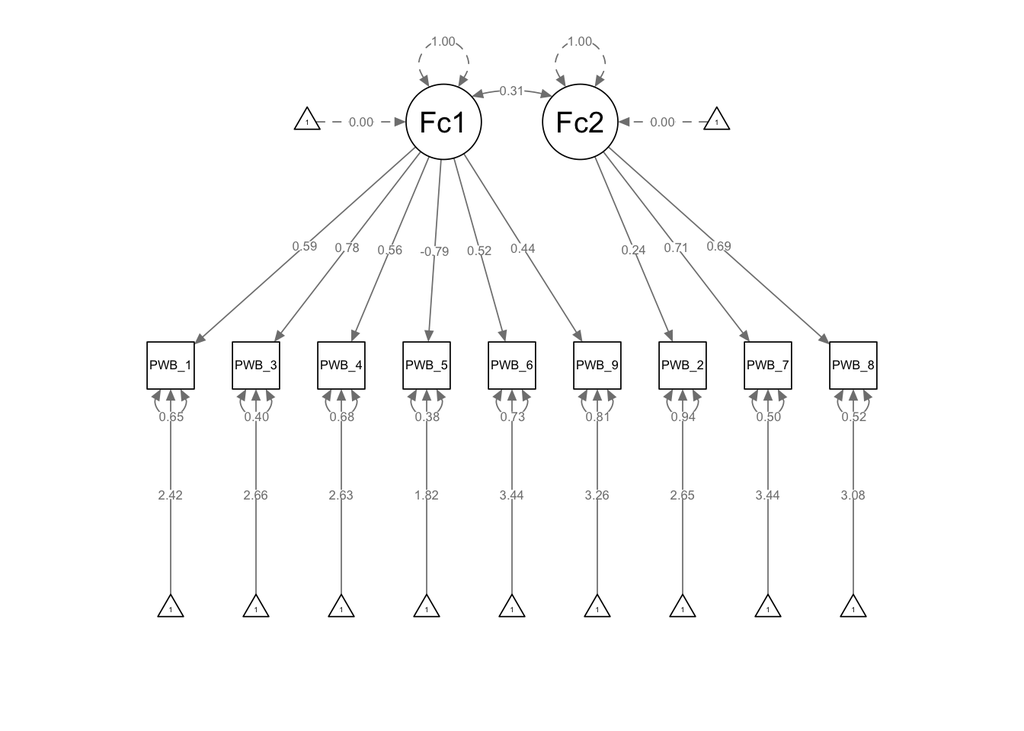

```r
semPaths(two.fit, whatLabels = "std", layout = "tree")
```

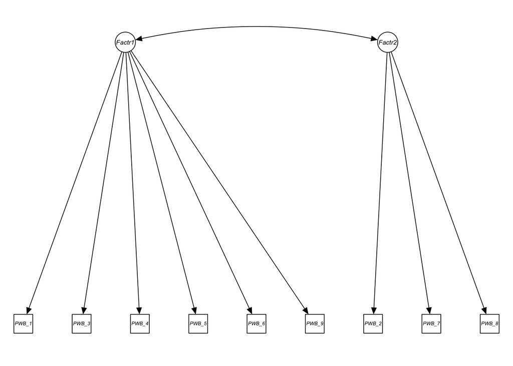

```r
semPaths(two.fit, intercepts = FALSE, residual = FALSE, layout = "tree2", sizeMan = 4, font = 3,
         sizeLat=4.3, bifactor = "Purpose",edge.color="black", nCharNodes = 6, mar = c(3, 1,3, 1))
```

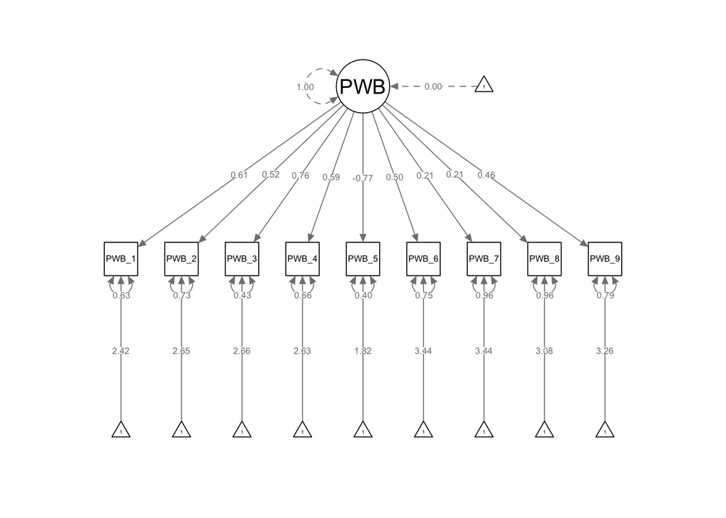

```r
semPaths(one.fit, whatLabels = "std", layout = "tree")
```

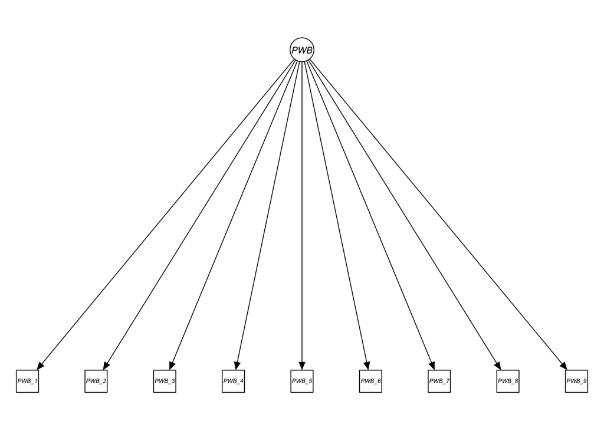

```r
semPaths(one.fit, intercepts = FALSE, residual = FALSE, layout = "tree2", sizeMan = 4, font = 3,
         sizeLat=4.3, bifactor = "Purpose",edge.color="black", nCharNodes = 6, mar = c(3, 1,3, 1))
```

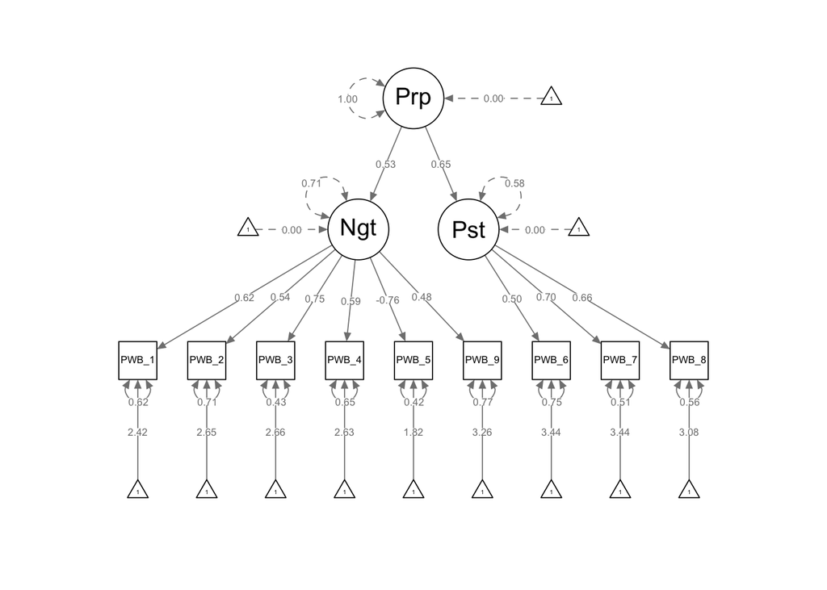

```r
semPaths(second.fit, whatLabels = "std", layout = "tree")
```

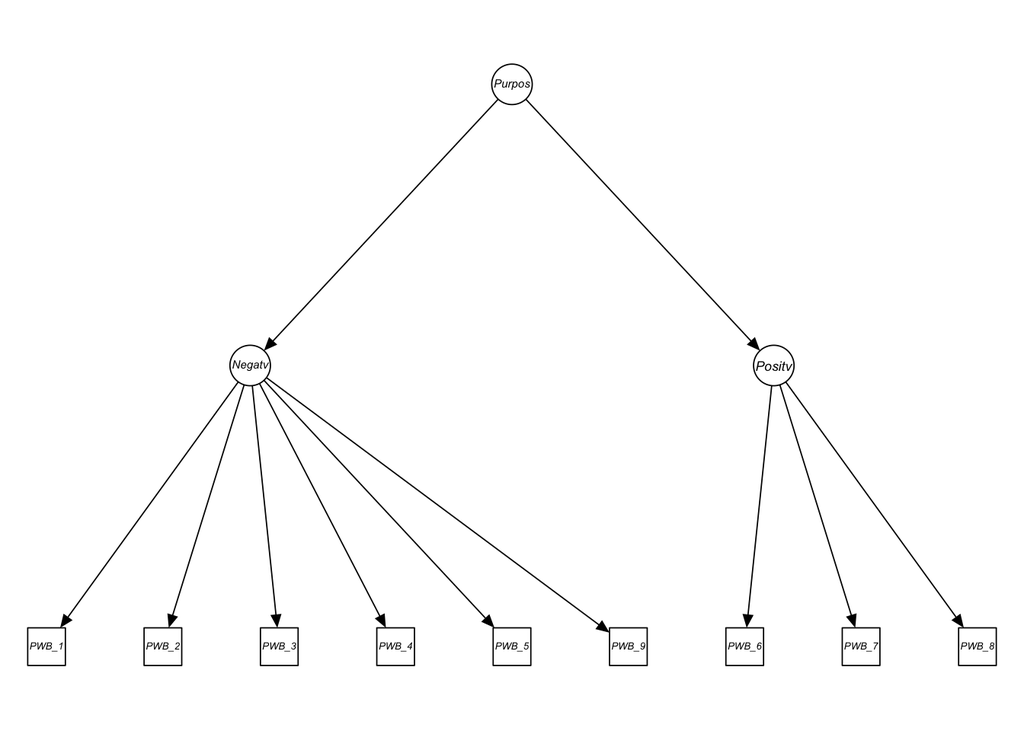

```r
semPaths(second.fit, intercepts = FALSE, residual = FALSE, layout = "tree2", sizeMan = 4, font = 3,
         sizeLat=4.3, bifactor = "Purpose",edge.color="black", nCharNodes = 6, mar = c(3, 1,3, 1))
```

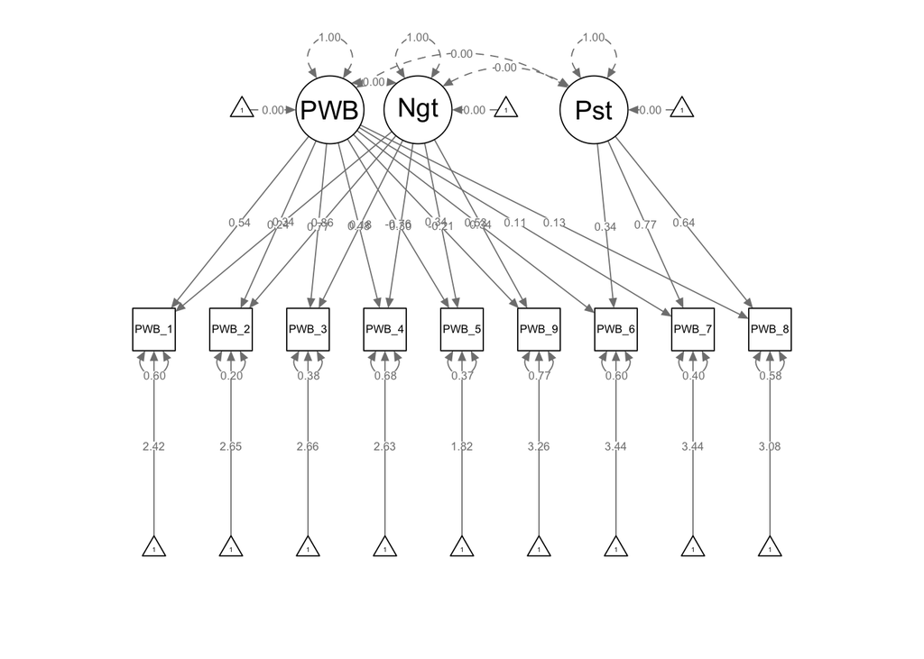

```r
semPaths(bifactor1.fit, whatLabels = "std", layout = "tree")
```

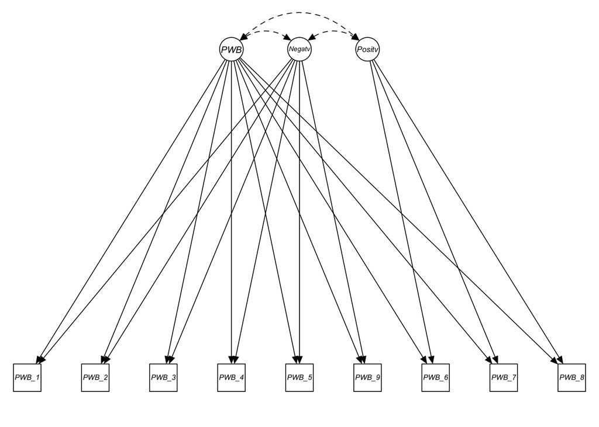

```r
semPaths(bifactor1.fit, intercepts = FALSE, residual = FALSE, layout = "tree2", sizeMan = 5, font = 3,
         sizeLat=4.3, bifactor = "Purpose",edge.color="black", nCharNodes = 6, mar = c(3, 1,3, 1))
```

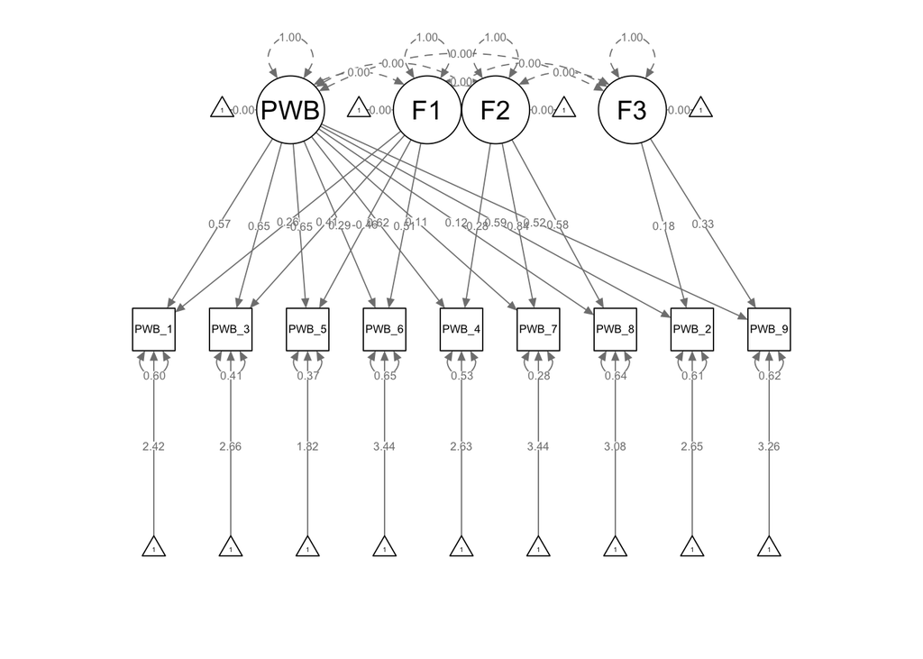

```r
semPaths(bifactor2.fit, whatLabels = "std", layout = "tree")
```

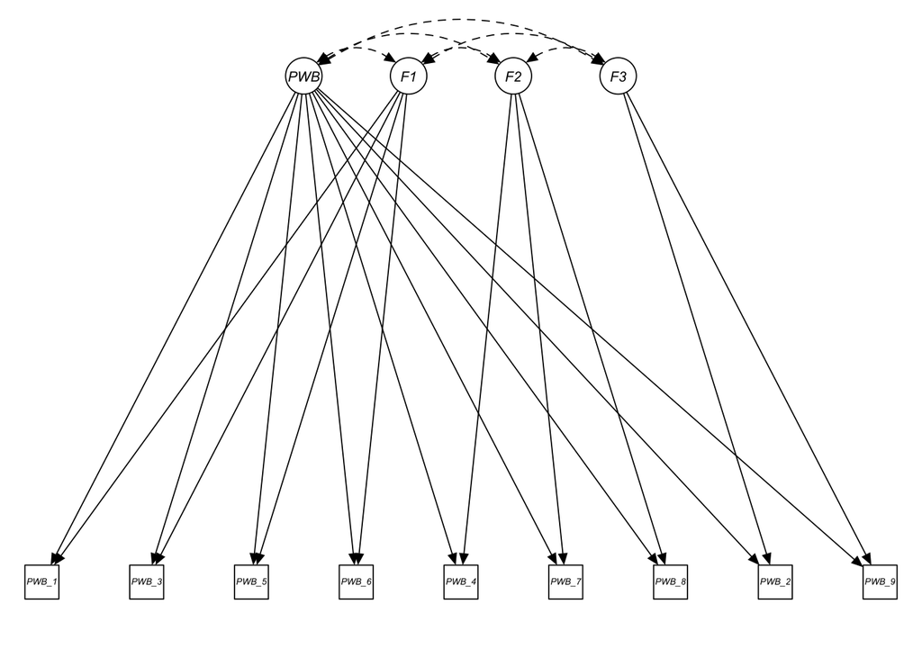

```r
semPaths(bifactor2.fit, intercepts = FALSE, residual = FALSE, layout = "tree2", sizeMan = 4, font = 3,
         sizeLat=4.3, bifactor = "Purpose",edge.color="black", nCharNodes = 6, mar = c(3, 1,3, 1))
```

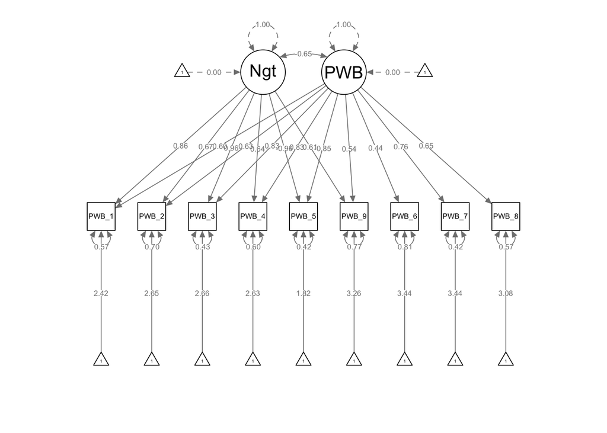

```r
semPaths(bifactorneg.fit, whatLabels = "std", layout = "tree")
```

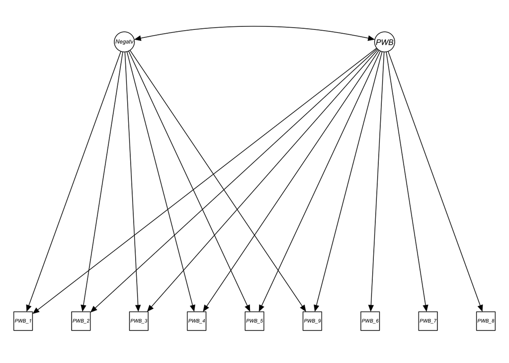

```r
semPaths(bifactorneg.fit, intercepts = FALSE, residual = FALSE, layout = "tree2", sizeMan = 4, font = 3,
         sizeLat=4.3, bifactor = "Purpose",edge.color="black", nCharNodes = 6, mar = c(3, 1,3, 1))
```

#summaries

```r
summary(two.fit, standardized = TRUE, rsquare=TRUE)
```

```
## lavaan (0.5-20) converged normally after  32 iterations
##
##                                                   Used       Total
##   Number of observations                           944        1288
##
##   Number of missing patterns                         1
##
##   Estimator                                         ML
##   Minimum Function Test Statistic              587.190
##   Degrees of freedom                                26
##   P-value (Chi-square)                           0.000
##
## Parameter Estimates:
##
##   Information                                 Observed
##   Standard Errors                             Standard
##
## Latent Variables:
##                    Estimate  Std.Err  Z-value  P(>|z|)   Std.lv  Std.all
##   Factor1 =~
##     PWB_1             0.947    0.052   18.368    0.000    0.947    0.595
##     PWB_3             1.212    0.047   25.767    0.000    1.212    0.778
##     PWB_4             0.852    0.050   17.174    0.000    0.852    0.565
##     PWB_5            -1.254    0.048  -26.153    0.000   -1.254   -0.787
##     PWB_6             0.673    0.043   15.563    0.000    0.673    0.518
##     PWB_9             0.638    0.050   12.873    0.000    0.638    0.438
##   Factor2 =~
##     PWB_2             0.353    0.060    5.882    0.000    0.353    0.244
##     PWB_7             0.920    0.059   15.513    0.000    0.920    0.706
##     PWB_8             0.966    0.063   15.422    0.000    0.966    0.691
##
## Covariances:
##                    Estimate  Std.Err  Z-value  P(>|z|)   Std.lv  Std.all
##   Factor1 ~~
##     Factor2           0.315    0.044    7.113    0.000    0.315    0.315
##
## Intercepts:
##                    Estimate  Std.Err  Z-value  P(>|z|)   Std.lv  Std.all
##     PWB_1             3.860    0.052   74.452    0.000    3.860    2.423
##     PWB_3             4.138    0.051   81.586    0.000    4.138    2.655
```

[output cut: 20 more lines]

```
##     PWB_8             1.023    0.105    9.761    0.000    1.023    0.523
##     Factor1           1.000                               1.000    1.000
##     Factor2           1.000                               1.000    1.000
##
## R-Square:
##                    Estimate
##     PWB_1             0.353
##     PWB_3             0.605
##     PWB_4             0.319
##     PWB_5             0.619
##     PWB_6             0.268
##     PWB_9             0.191
##     PWB_2             0.060
##     PWB_7             0.499
##     PWB_8             0.477
```

```r
(xtable(parameterEstimates(two.fit, ci = F, standardized = T,  fmi = F, remove.eq = F,
                   remove.ineq = F, remove.def = T)))
```

```
## % latex table generated in R 3.2.2 by xtable 1.8-0 package
## % Mon Jan 25 12:41:13 2016
## \begin{table}[ht]
## \centering
## \begin{tabular}{rlllrrrrrrr}
##   \hline
##  & lhs & op & rhs & est & se & z & pvalue & std.lv & std.all & std.nox \\
##   \hline
## 1 & Factor1 & =\~{} & PWB\_1 & 0.95 & 0.05 & 18.37 & 0.00 & 0.95 & 0.59 & 0.59 \\
##   2 & Factor1 & =\~{} & PWB\_3 & 1.21 & 0.05 & 25.77 & 0.00 & 1.21 & 0.78 & 0.78 \\
##   3 & Factor1 & =\~{} & PWB\_4 & 0.85 & 0.05 & 17.17 & 0.00 & 0.85 & 0.56 & 0.56 \\
##   4 & Factor1 & =\~{} & PWB\_5 & -1.25 & 0.05 & -26.15 & 0.00 & -1.25 & -0.79 & -0.79 \\
##   5 & Factor1 & =\~{} & PWB\_6 & 0.67 & 0.04 & 15.56 & 0.00 & 0.67 & 0.52 & 0.52 \\
##   6 & Factor1 & =\~{} & PWB\_9 & 0.64 & 0.05 & 12.87 & 0.00 & 0.64 & 0.44 & 0.44 \\
##   7 & Factor2 & =\~{} & PWB\_2 & 0.35 & 0.06 & 5.88 & 0.00 & 0.35 & 0.24 & 0.24 \\
```

[output cut: 28 more lines]

```r
summary(one.fit, standardized = TRUE, rsquare=TRUE)
```

```
## lavaan (0.5-20) converged normally after  24 iterations
##
##                                                   Used       Total
##   Number of observations                           944        1288
##
##   Number of missing patterns                         1
##
##   Estimator                                         ML
##   Minimum Function Test Statistic              643.119
##   Degrees of freedom                                27
##   P-value (Chi-square)                           0.000
##
## Parameter Estimates:
##
##   Information                                 Observed
##   Standard Errors                             Standard
##
## Latent Variables:
##                    Estimate  Std.Err  Z-value  P(>|z|)   Std.lv  Std.all
##   PWB =~
##     PWB_1             0.975    0.051   19.048    0.000    0.975    0.612
##     PWB_2             0.752    0.048   15.616    0.000    0.752    0.521
##     PWB_3             1.181    0.047   25.135    0.000    1.181    0.758
##     PWB_4             0.885    0.049   18.010    0.000    0.885    0.587
##     PWB_5            -1.229    0.048  -25.725    0.000   -1.229   -0.772
##     PWB_6             0.655    0.043   15.100    0.000    0.655    0.504
##     PWB_7             0.272    0.047    5.796    0.000    0.272    0.209
##     PWB_8             0.288    0.050    5.746    0.000    0.288    0.206
##     PWB_9             0.675    0.049   13.718    0.000    0.675    0.463
##
## Intercepts:
##                    Estimate  Std.Err  Z-value  P(>|z|)   Std.lv  Std.all
##     PWB_1             3.860    0.052   74.452    0.000    3.860    2.423
##     PWB_2             3.822    0.047   81.370    0.000    3.822    2.648
##     PWB_3             4.138    0.051   81.586    0.000    4.138    2.655
##     PWB_4             3.969    0.049   80.845    0.000    3.969    2.631
##     PWB_5             2.895    0.052   55.850    0.000    2.895    1.818
##     PWB_6             4.469    0.042  105.703    0.000    4.469    3.440
##     PWB_7             4.483    0.042  105.743    0.000    4.483    3.442
##     PWB_8             4.315    0.046   94.758    0.000    4.315    3.084
```

[output cut: 12 more lines]

```
##     PWB_8             1.874    0.087   21.496    0.000    1.874    0.958
##     PWB_9             1.673    0.082   20.479    0.000    1.673    0.786
##     PWB               1.000                               1.000    1.000
##
## R-Square:
##                    Estimate
##     PWB_1             0.375
##     PWB_2             0.272
##     PWB_3             0.574
##     PWB_4             0.344
##     PWB_5             0.595
##     PWB_6             0.254
##     PWB_7             0.044
##     PWB_8             0.042
##     PWB_9             0.214
```

```r
(xtable(parameterEstimates(one.fit, ci = F, standardized = T,  fmi = F, remove.eq = F,
                   remove.ineq = F, remove.def = T)))
```

```
## % latex table generated in R 3.2.2 by xtable 1.8-0 package
## % Mon Jan 25 12:41:13 2016
## \begin{table}[ht]
## \centering
## \begin{tabular}{rlllrrrrrrr}
##   \hline
##  & lhs & op & rhs & est & se & z & pvalue & std.lv & std.all & std.nox \\
##   \hline
## 1 & PWB & =\~{} & PWB\_1 & 0.98 & 0.05 & 19.05 & 0.00 & 0.98 & 0.61 & 0.61 \\
##   2 & PWB & =\~{} & PWB\_2 & 0.75 & 0.05 & 15.62 & 0.00 & 0.75 & 0.52 & 0.52 \\
##   3 & PWB & =\~{} & PWB\_3 & 1.18 & 0.05 & 25.13 & 0.00 & 1.18 & 0.76 & 0.76 \\
##   4 & PWB & =\~{} & PWB\_4 & 0.89 & 0.05 & 18.01 & 0.00 & 0.89 & 0.59 & 0.59 \\
##   5 & PWB & =\~{} & PWB\_5 & -1.23 & 0.05 & -25.73 & 0.00 & -1.23 & -0.77 & -0.77 \\
##   6 & PWB & =\~{} & PWB\_6 & 0.65 & 0.04 & 15.10 & 0.00 & 0.65 & 0.50 & 0.50 \\
##   7 & PWB & =\~{} & PWB\_7 & 0.27 & 0.05 & 5.80 & 0.00 & 0.27 & 0.21 & 0.21 \\
```

[output cut: 25 more lines]

```r
summary(second.fit, standardized = TRUE, rsquare=TRUE)
```

```
## lavaan (0.5-20) converged normally after  30 iterations
##
##                                                   Used       Total
##   Number of observations                           944        1288
##
##   Number of missing patterns                         1
##
##   Estimator                                         ML
##   Minimum Function Test Statistic              442.762
##   Degrees of freedom                                25
##   P-value (Chi-square)                           0.000
##
## Parameter Estimates:
##
##   Information                                 Observed
##   Standard Errors                             Standard
##
## Latent Variables:
##                    Estimate  Std.Err  Z-value  P(>|z|)   Std.lv  Std.all
##   Negative =~
##     PWB_1             0.829       NA                      0.981    0.616
##     PWB_2             0.661       NA                      0.782    0.542
##     PWB_3             0.994       NA                      1.176    0.755
##     PWB_4             0.752       NA                      0.890    0.590
##     PWB_5            -1.029       NA                     -1.218   -0.765
##     PWB_9             0.597       NA                      0.706    0.484
##   Positive =~
##     PWB_6             0.499       NA                      0.655    0.504
##     PWB_7             0.695       NA                      0.913    0.701
##     PWB_8             0.707       NA                      0.928    0.663
##   Purpose =~
##     Negative          0.633       NA                      0.535    0.535
##     Positive          0.851       NA                      0.648    0.648
##
## Intercepts:
##                    Estimate  Std.Err  Z-value  P(>|z|)   Std.lv  Std.all
##     PWB_1             3.860    0.052   74.452    0.000    3.860    2.423
##     PWB_2             3.822    0.047   81.370    0.000    3.822    2.648
##     PWB_3             4.138    0.051   81.586    0.000    4.138    2.655
##     PWB_4             3.969    0.049   80.845    0.000    3.969    2.631
```

[output cut: 22 more lines]

```
##     Purpose           1.000                               1.000    1.000
##
## R-Square:
##                    Estimate
##     PWB_1             0.379
##     PWB_2             0.294
##     PWB_3             0.570
##     PWB_4             0.348
##     PWB_5             0.584
##     PWB_9             0.234
##     PWB_6             0.254
##     PWB_7             0.492
##     PWB_8             0.440
##     Negative          0.286
##     Positive          0.420
```

```r
(xtable(parameterEstimates(second.fit, ci = F, standardized = T,  fmi = F, remove.eq = F,
                   remove.ineq = F, remove.def = T)))
```

```
## % latex table generated in R 3.2.2 by xtable 1.8-0 package
## % Mon Jan 25 12:41:13 2016
## \begin{table}[ht]
## \centering
## \begin{tabular}{rlllrrrrrrr}
##   \hline
##  & lhs & op & rhs & est & se & z & pvalue & std.lv & std.all & std.nox \\
##   \hline
## 1 & Negative & =\~{} & PWB\_1 & 0.83 &  &  &  & 0.98 & 0.62 & 0.62 \\
##   2 & Negative & =\~{} & PWB\_2 & 0.66 &  &  &  & 0.78 & 0.54 & 0.54 \\
##   3 & Negative & =\~{} & PWB\_3 & 0.99 &  &  &  & 1.18 & 0.75 & 0.75 \\
##   4 & Negative & =\~{} & PWB\_4 & 0.75 &  &  &  & 0.89 & 0.59 & 0.59 \\
##   5 & Negative & =\~{} & PWB\_5 & -1.03 &  &  &  & -1.22 & -0.76 & -0.76 \\
##   6 & Negative & =\~{} & PWB\_9 & 0.60 &  &  &  & 0.71 & 0.48 & 0.48 \\
##   7 & Positive & =\~{} & PWB\_6 & 0.50 &  &  &  & 0.65 & 0.50 & 0.50 \\
```

[output cut: 31 more lines]

```r
summary(bifactor1.fit, standardized = TRUE, rsquare=TRUE)
```

```
## lavaan (0.5-20) converged normally after  53 iterations
##
##                                                   Used       Total
##   Number of observations                           944        1288
##
##   Number of missing patterns                         1
##
##   Estimator                                         ML
##   Minimum Function Test Statistic              183.769
##   Degrees of freedom                                18
##   P-value (Chi-square)                           0.000
##
## Parameter Estimates:
##
##   Information                                 Observed
##   Standard Errors                             Standard
##
## Latent Variables:
##                    Estimate  Std.Err  Z-value  P(>|z|)   Std.lv  Std.all
##   PWB =~
##     PWB_1             0.854    0.074   11.612    0.000    0.854    0.536
##     PWB_2             0.353    0.094    3.765    0.000    0.353    0.245
##     PWB_3             1.195    0.058   20.615    0.000    1.195    0.767
##     PWB_4             0.717    0.076    9.433    0.000    0.717    0.475
##     PWB_5            -1.218    0.060  -20.420    0.000   -1.218   -0.765
##     PWB_6             0.692    0.049   14.145    0.000    0.692    0.532
##     PWB_7             0.148    0.050    2.950    0.003    0.148    0.113
##     PWB_8             0.176    0.053    3.331    0.001    0.176    0.126
##     PWB_9             0.503    0.086    5.880    0.000    0.503    0.345
##   Negative =~
##     PWB_1             0.543    0.108    5.029    0.000    0.543    0.341
##     PWB_2             1.240    0.185    6.697    0.000    1.240    0.859
##     PWB_3             0.276    0.117    2.368    0.018    0.276    0.177
##     PWB_4             0.457    0.113    4.055    0.000    0.457    0.303
##     PWB_5            -0.327    0.118   -2.767    0.006   -0.327   -0.206
##     PWB_9             0.493    0.128    3.846    0.000    0.493    0.338
##   Positive =~
##     PWB_6             0.446    0.045    9.826    0.000    0.446    0.344
##     PWB_7             1.001    0.069   14.561    0.000    1.001    0.768
##     PWB_8             0.893    0.066   13.444    0.000    0.893    0.639
```

[output cut: 35 more lines]

```
##     PWB               1.000                               1.000    1.000
##     Negative          1.000                               1.000    1.000
##     Positive          1.000                               1.000    1.000
##
## R-Square:
##                    Estimate
##     PWB_1             0.404
##     PWB_2             0.798
##     PWB_3             0.620
##     PWB_4             0.318
##     PWB_5             0.627
##     PWB_6             0.402
##     PWB_7             0.603
##     PWB_8             0.424
##     PWB_9             0.233
```

```r
(xtable(parameterEstimates(bifactor1.fit, ci = F, standardized = T,  fmi = F, remove.eq = F,
                   remove.ineq = F, remove.def = T)))
```

```
## % latex table generated in R 3.2.2 by xtable 1.8-0 package
## % Mon Jan 25 12:41:13 2016
## \begin{table}[ht]
## \centering
## \begin{tabular}{rlllrrrrrrr}
##   \hline
##  & lhs & op & rhs & est & se & z & pvalue & std.lv & std.all & std.nox \\
##   \hline
## 1 & PWB & =\~{} & PWB\_1 & 0.85 & 0.07 & 11.61 & 0.00 & 0.85 & 0.54 & 0.54 \\
##   2 & PWB & =\~{} & PWB\_2 & 0.35 & 0.09 & 3.77 & 0.00 & 0.35 & 0.24 & 0.24 \\
##   3 & PWB & =\~{} & PWB\_3 & 1.20 & 0.06 & 20.62 & 0.00 & 1.20 & 0.77 & 0.77 \\
##   4 & PWB & =\~{} & PWB\_4 & 0.72 & 0.08 & 9.43 & 0.00 & 0.72 & 0.48 & 0.48 \\
##   5 & PWB & =\~{} & PWB\_5 & -1.22 & 0.06 & -20.42 & 0.00 & -1.22 & -0.76 & -0.76 \\
##   6 & PWB & =\~{} & PWB\_6 & 0.69 & 0.05 & 14.15 & 0.00 & 0.69 & 0.53 & 0.53 \\
##   7 & PWB & =\~{} & PWB\_7 & 0.15 & 0.05 & 2.95 & 0.00 & 0.15 & 0.11 & 0.11 \\
```

[output cut: 41 more lines]

```r
summary(bifactor2.fit, standardized = TRUE, rsquare=TRUE)
```

```
## lavaan (0.5-20) converged normally after  46 iterations
##
##                                                   Used       Total
##   Number of observations                           944        1288
##
##   Number of missing patterns                         1
##
##   Estimator                                         ML
##   Minimum Function Test Statistic              236.692
##   Degrees of freedom                                18
##   P-value (Chi-square)                           0.000
##
## Parameter Estimates:
##
##   Information                                 Observed
##   Standard Errors                             Standard
##
## Latent Variables:
##                    Estimate  Std.Err  Z-value  P(>|z|)   Std.lv  Std.all
##   PWB =~
##     PWB_1             0.913    0.060   15.187    0.000    0.913    0.573
##     PWB_2             0.857    0.055   15.647    0.000    0.857    0.594
##     PWB_3             1.018    0.060   17.031    0.000    1.018    0.653
##     PWB_4             0.939    0.054   17.383    0.000    0.939    0.623
##     PWB_5            -1.031    0.061  -16.954    0.000   -1.031   -0.648
##     PWB_6             0.379    0.056    6.731    0.000    0.379    0.292
##     PWB_7             0.139    0.054    2.555    0.011    0.139    0.107
##     PWB_8             0.174    0.057    3.041    0.002    0.174    0.125
##     PWB_9             0.757    0.055   13.795    0.000    0.757    0.519
##   F1 =~
##     PWB_1             0.415    0.076    5.455    0.000    0.415    0.260
##     PWB_3             0.634    0.075    8.471    0.000    0.634    0.407
##     PWB_5            -0.733    0.080   -9.188    0.000   -0.733   -0.460
##     PWB_6             0.669    0.080    8.376    0.000    0.669    0.515
##   F2 =~
##     PWB_4             0.422    0.056    7.513    0.000    0.422    0.280
##     PWB_7             1.096    0.089   12.326    0.000    1.096    0.842
##     PWB_8             0.817    0.075   10.907    0.000    0.817    0.584
##   F3 =~
##     PWB_2             0.261       NA                      0.261    0.181
```

[output cut: 42 more lines]

```
##     F1                1.000                               1.000    1.000
##     F2                1.000                               1.000    1.000
##     F3                1.000                               1.000    1.000
##
## R-Square:
##                    Estimate
##     PWB_1             0.396
##     PWB_2             0.386
##     PWB_3             0.592
##     PWB_4             0.466
##     PWB_5             0.631
##     PWB_6             0.350
##     PWB_7             0.720
##     PWB_8             0.357
##     PWB_9             0.377
```

```r
(xtable(parameterEstimates(bifactor2.fit, ci = F, standardized = T,  fmi = F, remove.eq = F,
                   remove.ineq = F, remove.def = T)))
```

```
## % latex table generated in R 3.2.2 by xtable 1.8-0 package
## % Mon Jan 25 12:41:13 2016
## \begin{table}[ht]
## \centering
## \begin{tabular}{rlllrrrrrrr}
##   \hline
##  & lhs & op & rhs & est & se & z & pvalue & std.lv & std.all & std.nox \\
##   \hline
## 1 & PWB & =\~{} & PWB\_1 & 0.91 & 0.06 & 15.19 & 0.00 & 0.91 & 0.57 & 0.57 \\
##   2 & PWB & =\~{} & PWB\_2 & 0.86 & 0.05 & 15.65 & 0.00 & 0.86 & 0.59 & 0.59 \\
##   3 & PWB & =\~{} & PWB\_3 & 1.02 & 0.06 & 17.03 & 0.00 & 1.02 & 0.65 & 0.65 \\
##   4 & PWB & =\~{} & PWB\_4 & 0.94 & 0.05 & 17.38 & 0.00 & 0.94 & 0.62 & 0.62 \\
##   5 & PWB & =\~{} & PWB\_5 & -1.03 & 0.06 & -16.95 & 0.00 & -1.03 & -0.65 & -0.65 \\
##   6 & PWB & =\~{} & PWB\_6 & 0.38 & 0.06 & 6.73 & 0.00 & 0.38 & 0.29 & 0.29 \\
##   7 & PWB & =\~{} & PWB\_7 & 0.14 & 0.05 & 2.56 & 0.01 & 0.14 & 0.11 & 0.11 \\
```

[output cut: 46 more lines]

```r
summary(bifactor.negative.fit, standardized = TRUE, rsquare=TRUE)
```

```
## lavaan (0.5-20) converged normally after  32 iterations
##
##                                                   Used       Total
##   Number of observations                           944        1288
##
##   Number of missing patterns                         1
##
##   Estimator                                         ML
##   Minimum Function Test Statistic              357.805
##   Degrees of freedom                                20
##   P-value (Chi-square)                           0.000
##
## Parameter Estimates:
##
##   Information                                 Observed
##   Standard Errors                             Standard
##
## Latent Variables:
##                    Estimate  Std.Err  Z-value  P(>|z|)   Std.lv  Std.all
##   Negative =~
##     PWB_1             1.373   25.379    0.054    0.957    1.373    0.862
##     PWB_2             0.969   17.923    0.054    0.957    0.969    0.672
##     PWB_3             1.493   27.601    0.054    0.957    1.493    0.958
##     PWB_4             0.962   17.783    0.054    0.957    0.962    0.638
##     PWB_5            -1.535   28.388   -0.054    0.957   -1.535   -0.964
##     PWB_9             0.886   16.380    0.054    0.957    0.886    0.607
##   PWB =~
##     PWB_1             0.949   38.938    0.024    0.981    0.949    0.596
##     PWB_2             0.910   27.499    0.033    0.974    0.910    0.631
##     PWB_3             1.286   42.347    0.030    0.976    1.286    0.825
##     PWB_4             1.250   27.283    0.046    0.963    1.250    0.828
##     PWB_5            -1.348   43.554   -0.031    0.975   -1.348   -0.846
##     PWB_6             0.569    0.051   11.216    0.000    0.569    0.438
##     PWB_7             0.994    0.052   19.087    0.000    0.994    0.763
##     PWB_8             0.913    0.052   17.517    0.000    0.913    0.653
##     PWB_9             0.789   25.132    0.031    0.975    0.789    0.541
##
## Covariances:
##                    Estimate  Std.Err  Z-value  P(>|z|)   Std.lv  Std.all
##   Negative ~~
```

[output cut: 26 more lines]

```
##     PWB_8             1.123    0.079   14.159    0.000    1.123    0.574
##     Negative          1.000                               1.000    1.000
##     PWB               1.000                               1.000    1.000
##
## R-Square:
##                    Estimate
##     PWB_1             0.428
##     PWB_2             0.297
##     PWB_3             0.568
##     PWB_4             0.404
##     PWB_5             0.582
##     PWB_9             0.233
##     PWB_6             0.192
##     PWB_7             0.583
##     PWB_8             0.426
```

```r
(xtable(parameterEstimates(bifactor.negative.fit, ci = F, standardized = T,  fmi = F, remove.eq = F,
                   remove.ineq = F, remove.def = T)))
```

```
## % latex table generated in R 3.2.2 by xtable 1.8-0 package
## % Mon Jan 25 12:41:13 2016
## \begin{table}[ht]
## \centering
## \begin{tabular}{rlllrrrrrrr}
##   \hline
##  & lhs & op & rhs & est & se & z & pvalue & std.lv & std.all & std.nox \\
##   \hline
## 1 & Negative & =\~{} & PWB\_1 & 1.37 & 25.38 & 0.05 & 0.96 & 1.37 & 0.86 & 0.86 \\
##   2 & Negative & =\~{} & PWB\_2 & 0.97 & 17.92 & 0.05 & 0.96 & 0.97 & 0.67 & 0.67 \\
##   3 & Negative & =\~{} & PWB\_3 & 1.49 & 27.60 & 0.05 & 0.96 & 1.49 & 0.96 & 0.96 \\
##   4 & Negative & =\~{} & PWB\_4 & 0.96 & 17.78 & 0.05 & 0.96 & 0.96 & 0.64 & 0.64 \\
##   5 & Negative & =\~{} & PWB\_5 & -1.54 & 28.39 & -0.05 & 0.96 & -1.54 & -0.96 & -0.96 \\
##   6 & Negative & =\~{} & PWB\_9 & 0.89 & 16.38 & 0.05 & 0.96 & 0.89 & 0.61 & 0.61 \\
##   7 & PWB & =\~{} & PWB\_1 & 0.95 & 38.94 & 0.02 & 0.98 & 0.95 & 0.60 & 0.60 \\
```

[output cut: 34 more lines]

```r
?parameterEstimates
```

# Residual correlations

```r
correl = residuals(two.fit, type="cor")
correl
```

```
## $type
## [1] "cor.bollen"
##
## $cor
##       PWB_1  PWB_3  PWB_4  PWB_5  PWB_6  PWB_9  PWB_2  PWB_7  PWB_8
## PWB_1  0.000
## PWB_3  0.001  0.000
## PWB_4 -0.041  0.018  0.000
## PWB_5 -0.018 -0.006  0.033  0.000
## PWB_6  0.021 -0.006 -0.031 -0.011  0.000
## PWB_9  0.030 -0.011  0.071 -0.007 -0.124  0.000
## PWB_2  0.386  0.277  0.334 -0.302  0.106  0.334  0.000
## PWB_7 -0.175 -0.096  0.176  0.070  0.209 -0.014 -0.040  0.000
## PWB_8 -0.138 -0.071  0.118  0.068  0.174  0.001 -0.050  0.017  0.000
##
## $mean
## PWB_1 PWB_3 PWB_4 PWB_5 PWB_6 PWB_9 PWB_2 PWB_7 PWB_8
##     0     0     0     0     0     0     0     0     0
```

```r
View(correl$cor)
correl1 = residuals(one.fit, type="cor")
correl1
```

```
## $type
## [1] "cor.bollen"
##
## $cor
##       PWB_1  PWB_2  PWB_3  PWB_4  PWB_5  PWB_6  PWB_7  PWB_8  PWB_9
## PWB_1  0.000
## PWB_2  0.113  0.000
## PWB_3  0.000 -0.058  0.000
## PWB_4 -0.065  0.072  0.012  0.000
## PWB_5 -0.014  0.039 -0.033  0.041  0.000
## PWB_6  0.020 -0.117  0.015 -0.034 -0.030  0.000
## PWB_7 -0.170  0.024 -0.081  0.179  0.056  0.219  0.000
## PWB_8 -0.134  0.011 -0.058  0.120  0.055  0.183  0.462  0.000
## PWB_9  0.007  0.126 -0.021  0.047  0.005 -0.131 -0.013  0.001  0.000
##
## $mean
## PWB_1 PWB_2 PWB_3 PWB_4 PWB_5 PWB_6 PWB_7 PWB_8 PWB_9
##     0     0     0     0     0     0     0     0     0
```

```r
View(correl1$cor)
correl0 = residuals(second.fit, type="cor")
correl0
```

```
## $type
## [1] "cor.bollen"
##
## $cor
##       PWB_1  PWB_2  PWB_3  PWB_4  PWB_5  PWB_9  PWB_6  PWB_7  PWB_8
## PWB_1  0.000
## PWB_2  0.098  0.000
## PWB_3 -0.001 -0.072  0.000
## PWB_4 -0.069  0.058  0.012  0.000
## PWB_5 -0.016  0.051 -0.041  0.040  0.000
## PWB_9 -0.008  0.105 -0.036  0.033  0.018  0.000
## PWB_6  0.222  0.052  0.265  0.159 -0.285  0.018  0.000
## PWB_7 -0.192  0.001 -0.107  0.159  0.080 -0.034 -0.029  0.000
## PWB_8 -0.150 -0.006 -0.076  0.105  0.072 -0.015 -0.048  0.040  0.000
##
## $mean
## PWB_1 PWB_2 PWB_3 PWB_4 PWB_5 PWB_9 PWB_6 PWB_7 PWB_8
##     0     0     0     0     0     0     0     0     0
```

```r
View(correl0$cor)
correl4 = residuals(bifactor1.fit, type="cor")
correl4
```

```
## $type
## [1] "cor.bollen"
##
## $cor
##       PWB_1  PWB_2  PWB_3  PWB_4  PWB_5  PWB_6  PWB_7  PWB_8  PWB_9
## PWB_1  0.000
## PWB_2  0.008  0.000
## PWB_3 -0.008 -0.003  0.000
## PWB_4 -0.064  0.001  0.039  0.000
## PWB_5 -0.006  0.001  0.005  0.014  0.000
## PWB_6  0.044  0.016 -0.011  0.009 -0.011  0.000
## PWB_7 -0.103  0.105 -0.010  0.248 -0.019  0.000  0.000
## PWB_8 -0.076  0.088  0.001  0.181 -0.007  0.000  0.000  0.000
## PWB_9 -0.010 -0.007  0.005  0.052 -0.019 -0.081  0.044  0.053  0.000
##
## $mean
## PWB_1 PWB_2 PWB_3 PWB_4 PWB_5 PWB_6 PWB_7 PWB_8 PWB_9
##     0     0     0     0     0     0     0     0     0
```

```r
View(correl4$cor)
correl5 = residuals(bifactor2.fit, type="cor")
correl5
```

```
## $type
## [1] "cor.bollen"
##
## $cor
##       PWB_1  PWB_2  PWB_3  PWB_4  PWB_5  PWB_6  PWB_7  PWB_8  PWB_9
## PWB_1  0.000
## PWB_2  0.092  0.000
## PWB_3 -0.017 -0.051  0.000
## PWB_4 -0.062  0.008  0.050  0.000
## PWB_5  0.004  0.022 -0.008 -0.008  0.000
## PWB_6  0.028 -0.027 -0.003  0.080  0.007  0.000
## PWB_7 -0.104  0.070  0.007  0.000 -0.036  0.293  0.000
## PWB_8 -0.080  0.044  0.016  0.000 -0.023  0.250  0.000  0.000
## PWB_9 -0.007  0.000 -0.009 -0.005 -0.016 -0.049  0.028  0.032  0.000
##
## $mean
## PWB_1 PWB_2 PWB_3 PWB_4 PWB_5 PWB_6 PWB_7 PWB_8 PWB_9
##     0     0     0     0     0     0     0     0     0
```

```r
correl3 = residuals(bifactor.negative.fit, type="cor")
correl3
```

```
## $type
## [1] "cor.bollen"
##
## $cor
##       PWB_1  PWB_2  PWB_3  PWB_4  PWB_5  PWB_9  PWB_6  PWB_7  PWB_8
## PWB_1  0.000
## PWB_2  0.092  0.000
## PWB_3 -0.018 -0.072  0.000
## PWB_4 -0.036  0.052  0.023  0.000
## PWB_5 -0.001  0.052 -0.043  0.032  0.000
## PWB_9 -0.016  0.105 -0.034  0.036  0.017  0.000
## PWB_6  0.314  0.062  0.309  0.081 -0.323  0.039  0.000
## PWB_7 -0.068 -0.014 -0.077 -0.013  0.061 -0.028 -0.010  0.000
## PWB_8 -0.031 -0.007 -0.033 -0.028  0.039  0.002  0.001  0.007  0.000
##
## $mean
## PWB_1 PWB_2 PWB_3 PWB_4 PWB_5 PWB_9 PWB_6 PWB_7 PWB_8
##     0     0     0     0     0     0     0     0     0
```

```r
View(correl3$cor)
```

# Modification indicies

```r
#modindices(two.fit, sort. = TRUE, minimum.value = 3.84)
#modindices(one.fit, sort. = TRUE, minimum.value = 3.84)
#modindices(bifactor1.fit, sort. = TRUE, minimum.value = 3.84)
#modindices(bifactor.negative.fit, sort. = TRUE, minimum.value = 3.84)
```

# Fit Measures

```r
fitmeasures(two.fit)#Models two factors:Positive and Negative for Purpose
```

```
##                npar                fmin               chisq
##              28.000               0.311             587.190
##                  df              pvalue      baseline.chisq
##              26.000               0.000            2337.145
##         baseline.df     baseline.pvalue                 cfi
##              36.000               0.000               0.756
##                 tli                nnfi                 rfi
##               0.662               0.662               0.652
##                 nfi                pnfi                 ifi
##               0.749               0.541               0.757
##                 rni                logl   unrestricted.logl
##               0.756          -14382.524          -14088.929
##                 aic                 bic              ntotal
##           28821.048           28956.852             944.000
##                bic2               rmsea      rmsea.ci.lower
##           28867.925               0.151               0.141
##      rmsea.ci.upper        rmsea.pvalue                 rmr
##               0.162               0.000               0.258
##          rmr_nomean                srmr        srmr_bentler
##               0.283               0.120               0.120
## srmr_bentler_nomean         srmr_bollen  srmr_bollen_nomean
##               0.131               0.120               0.131
##          srmr_mplus   srmr_mplus_nomean               cn_05
##               0.120               0.131              63.514
##               cn_01                 gfi                agfi
##              74.376               0.993               0.985
##                pgfi                 mfi                ecvi
##               0.478               0.743                  NA
```

```r
fitmeasures(one.fit) #Models as a single purpose factor
```

```
##                npar                fmin               chisq
##              27.000               0.341             643.119
##                  df              pvalue      baseline.chisq
##              27.000               0.000            2337.145
##         baseline.df     baseline.pvalue                 cfi
##              36.000               0.000               0.732
##                 tli                nnfi                 rfi
##               0.643               0.643               0.633
##                 nfi                pnfi                 ifi
##               0.725               0.544               0.733
##                 rni                logl   unrestricted.logl
##               0.732          -14410.488          -14088.929
##                 aic                 bic              ntotal
##           28874.977           29005.930             944.000
##                bic2               rmsea      rmsea.ci.lower
##           28920.180               0.155               0.145
##      rmsea.ci.upper        rmsea.pvalue                 rmr
##               0.166               0.000               0.182
##          rmr_nomean                srmr        srmr_bentler
##               0.200               0.095               0.095
## srmr_bentler_nomean         srmr_bollen  srmr_bollen_nomean
##               0.104               0.095               0.104
##          srmr_mplus   srmr_mplus_nomean               cn_05
##               0.095               0.104              59.880
##               cn_01                 gfi                agfi
##              69.934               0.991               0.982
##                pgfi                 mfi                ecvi
##               0.496               0.722                  NA
```

```r
fitmeasures(second.fit)#Second order models as Purpose being the higher factor made up of Purpose and Positive
```

```
##                npar                fmin               chisq
##              29.000               0.235             442.762
##                  df              pvalue      baseline.chisq
##              25.000               0.000            2337.145
##         baseline.df     baseline.pvalue                 cfi
##              36.000               0.000               0.818
##                 tli                nnfi                 rfi
##               0.739               0.739               0.727
##                 nfi                pnfi                 ifi
##               0.811               0.563               0.819
##                 rni                logl   unrestricted.logl
##               0.818          -14310.310          -14088.929
##                 aic                 bic              ntotal
##           28678.620           28819.273             944.000
##                bic2               rmsea      rmsea.ci.lower
##           28727.171               0.133               0.122
##      rmsea.ci.upper        rmsea.pvalue                 rmr
##               0.144               0.000               0.179
##          rmr_nomean                srmr        srmr_bentler
##               0.197               0.086               0.086
## srmr_bentler_nomean         srmr_bollen  srmr_bollen_nomean
##               0.095               0.086               0.095
##          srmr_mplus   srmr_mplus_nomean               cn_05
##               0.086               0.095              81.278
##               cn_01                 gfi                agfi
##              95.481               0.993               0.985
##                pgfi                 mfi                ecvi
##               0.460               0.801                  NA
```

```r
fitmeasures(bifactor1.fit)#Models bifactor with Positive and Purpose as factors uncorolated with the main factor
```

```
##                npar                fmin               chisq
##              36.000               0.097             183.769
##                  df              pvalue      baseline.chisq
##              18.000               0.000            2337.145
##         baseline.df     baseline.pvalue                 cfi
##              36.000               0.000               0.928
##                 tli                nnfi                 rfi
##               0.856               0.856               0.843
##                 nfi                pnfi                 ifi
##               0.921               0.461               0.929
##                 rni                logl   unrestricted.logl
##               0.928          -14180.814          -14088.929
##                 aic                 bic              ntotal
##           28433.627           28608.232             944.000
##                bic2               rmsea      rmsea.ci.lower
##           28493.898               0.099               0.086
##      rmsea.ci.upper        rmsea.pvalue                 rmr
##               0.112               0.000               0.108
##          rmr_nomean                srmr        srmr_bentler
##               0.119               0.053               0.053
## srmr_bentler_nomean         srmr_bollen  srmr_bollen_nomean
##               0.058               0.053               0.058
##          srmr_mplus   srmr_mplus_nomean               cn_05
##               0.053               0.058             149.298
##               cn_01                 gfi                agfi
##             179.790               0.997               0.992
##                pgfi                 mfi                ecvi
##               0.332               0.916                  NA
```

```r
fitmeasures(bifactor2.fit)#Models bifactor with Positive and Purpose as factors uncorolated with the main factor
```

```
##                npar                fmin               chisq
##              36.000               0.125             236.692
##                  df              pvalue      baseline.chisq
##              18.000               0.000            2337.145
##         baseline.df     baseline.pvalue                 cfi
##              36.000               0.000               0.905
##                 tli                nnfi                 rfi
##               0.810               0.810               0.797
##                 nfi                pnfi                 ifi
##               0.899               0.449               0.906
##                 rni                logl   unrestricted.logl
##               0.905          -14207.275          -14088.929
##                 aic                 bic              ntotal
##           28486.550           28661.154             944.000
##                bic2               rmsea      rmsea.ci.lower
##           28546.820               0.113               0.101
##      rmsea.ci.upper        rmsea.pvalue                 rmr
##               0.127               0.000               0.115
##          rmr_nomean                srmr        srmr_bentler
##               0.126               0.062               0.062
## srmr_bentler_nomean         srmr_bollen  srmr_bollen_nomean
##               0.068               0.062               0.068
##          srmr_mplus   srmr_mplus_nomean               cn_05
##               0.062               0.068             116.140
##               cn_01                 gfi                agfi
##             139.814               0.997               0.991
##                pgfi                 mfi                ecvi
##               0.332               0.891                  NA
```

```r
fitmeasures(bifactor.negative.fit)#Models bifactor as the negatively worded item as a factor uncorolated with the main factor
```

```
##                npar                fmin               chisq
##              34.000               0.190             357.805
##                  df              pvalue      baseline.chisq
##              20.000               0.000            2337.145
##         baseline.df     baseline.pvalue                 cfi
##              36.000               0.000               0.853
##                 tli                nnfi                 rfi
##               0.736               0.736               0.724
##                 nfi                pnfi                 ifi
##               0.847               0.471               0.854
##                 rni                logl   unrestricted.logl
##               0.853          -14267.831          -14088.929
##                 aic                 bic              ntotal
##           28603.663           28768.567             944.000
##                bic2               rmsea      rmsea.ci.lower
##           28660.585               0.134               0.122
##      rmsea.ci.upper        rmsea.pvalue                 rmr
##               0.146               0.000               0.171
##          rmr_nomean                srmr        srmr_bentler
##               0.188               0.083               0.083
## srmr_bentler_nomean         srmr_bollen  srmr_bollen_nomean
##               0.091               0.083               0.091
##          srmr_mplus   srmr_mplus_nomean               cn_05
##               0.083               0.091              83.870
##               cn_01                 gfi                agfi
##             100.111               0.995               0.986
##                pgfi                 mfi                ecvi
##               0.368               0.836                  NA
```

# Create dataset for Target rotation

```r
all_surveys <- read.csv("~/Dropbox/Git/stats/allsurveysYT1_Jan2016.csv", header=T)
PWBTR<-select(all_surveys, PWB_1, PWB_2, PWB_3,PWB_4, PWB_5,PWB_6,PWB_9, PWB_8,PWB_7)
PWB$PWB_1  <-  7- PWB$PWB_1
PWB$PWB_2  <-  7- PWB$PWB_2
PWB$PWB_3  <-  7- PWB$PWB_3
PWB$PWB_4  <-  7- PWB$PWB_4
PWB$PWB_9  <-  7- PWB$PWB_9
PWBTR<- data.frame(apply(PWBTR,2, as.numeric))

library(GPArotation)
library(psych)
library(dplyr)

PWBTR<-tbl_df(PWBTR)
PWBTR
```

```
## Source: local data frame [1,288 x 9]
##
##    PWB_1 PWB_2 PWB_3 PWB_4 PWB_5 PWB_6 PWB_9 PWB_8 PWB_7
##    (dbl) (dbl) (dbl) (dbl) (dbl) (dbl) (dbl) (dbl) (dbl)
## 1      3     1     2     4     5     4     6     5     3
## 2      5     5     3     3     6     1     4     4     2
## 3      5     4     4     5     5     4     5     6     6
## 4      2     5     2     2     3     5     1     4     4
## 5      4     4     4     4     4     4     4     4     4
## 6      6     5     5     5     4     4     5     4     4
## 7      4     3     4     3     3     3     3     3     4
## 8      6     5     6     6     6     6     6     6     2
## 9      2     2     2     2     1     5     2     5     5
## 10     5     5     5     5     5     5     5     5     5
## ..   ...   ...   ...   ...   ...   ...   ...   ...   ...
```

```r
str(PWBTR)
```

```
## Classes 'tbl_df', 'tbl' and 'data.frame':    1288 obs. of  9 variables:
##  $ PWB_1: num  3 5 5 2 4 6 4 6 2 5 ...
##  $ PWB_2: num  1 5 4 5 4 5 3 5 2 5 ...
##  $ PWB_3: num  2 3 4 2 4 5 4 6 2 5 ...
##  $ PWB_4: num  4 3 5 2 4 5 3 6 2 5 ...
##  $ PWB_5: num  5 6 5 3 4 4 3 6 1 5 ...
##  $ PWB_6: num  4 1 4 5 4 4 3 6 5 5 ...
##  $ PWB_9: num  6 4 5 1 4 5 3 6 2 5 ...
##  $ PWB_8: num  5 4 6 4 4 4 3 6 5 5 ...
##  $ PWB_7: num  3 2 6 4 4 4 4 2 5 5 ...
```

```r
colnames(PWBTR) <- c("1","2", "3", "4", "5", "6", "7", "8", "9")
#Target rotation: choose "simple structure" a priori and can be applied to oblique and orthogonal rotation based on
#what paper says facotrs should be PWB
Targ_key <- make.keys(9,list(f1=1:6,f2=7:9))
Targ_key <- scrub(Targ_key,isvalue=1)  #fix the 0s, allow the NAs to be estimated
Targ_key <- list(Targ_key)
PWBTR_cor <- corFiml(PWBTR) # convert the raw data to correlation matrix uisng FIML
out_targetQ <- fa(PWBTR_cor,2,rotate="TargetQ",n.obs = 816,Target=Targ_key) #TargetT for orthogonal rotation
fa2latex(fa(PWBTR_cor,2,rotate="TargetQ",n.obs = 816,Target=Targ_key), heading="Table 7. Factor Loadings for Exploratory Factor Analysis PWB")
```

```
## % Called in the psych package  fa2latex % Called in the psych package  fa(PWBTR_cor, 2, rotate = "TargetQ", n.obs = 816, Target = Targ_key) % Called in the psych package  Table 7. Factor Loadings for Exploratory Factor Analysis PWB
## \begin{table}[htpb]\caption{fa2latex}
## \begin{center}
## \begin{scriptsize}
## \begin{tabular} {l r r r r r }
##  \multicolumn{ 5 }{l}{ Table 7. Factor Loadings for Exploratory Factor Analysis PWB } \cr
##  \hline Variable  &   MR1  &  MR2  &  h2  &  u2  &  com \cr
##   \hline
## 1   &  \bf{ 0.68}  &   0.19  &  0.44  &  0.56  &  1.16 \cr
##  2   &  \bf{ 0.51}  &  -0.03  &  0.27  &  0.73  &  1.01 \cr
##  3   &  \bf{ 0.78}  &   0.06  &  0.59  &  0.41  &  1.01 \cr
##  4   &  \bf{ 0.53}  &  -0.24  &  0.39  &  0.61  &  1.39 \cr
##  5   &  \bf{ 0.79}  &   0.05  &  0.60  &  0.40  &  1.01 \cr
##  6   &  \bf{-0.44}  &   0.28  &  0.32  &  0.68  &  1.69 \cr
##  7   &  \bf{ 0.46}  &   0.00  &  0.21  &  0.79  &  1.00 \cr
##  8   &  -0.05  &  \bf{ 0.60}  &  0.38  &  0.62  &  1.02 \cr
##  9   &  -0.01  &  \bf{ 0.83}  &  0.70  &  0.30  &  1.00 \cr
## \hline \cr SS loadings & 2.64 &  1.25 &  \cr
## \cr
##             \hline \cr
## MR1   &  1.00 & -0.21 \cr
##  MR2   & -0.21 &  1.00 \cr
##  \hline
## \end{tabular}
## \end{scriptsize}
## \end{center}
## \label{default}
## \end{table}
```

```r
out_targetQ[c("loadings", "score.cor", "TLI", "RMSEA")]
```

```
## $loadings
##
## Loadings:
##   MR1    MR2
## 1  0.675  0.192
## 2  0.514
## 3  0.777
## 4  0.527 -0.236
## 5  0.785
## 6 -0.440  0.277
## 7  0.461
## 8         0.603
## 9         0.833
##
##                  MR1   MR2
## SS loadings    2.628 1.234
## Proportion Var 0.292 0.137
## Cumulative Var 0.292 0.429
##
## $score.cor
##            [,1]       [,2]
## [1,]  1.0000000 -0.2350767
## [2,] -0.2350767  1.0000000
##
## $TLI
## [1] 0.8557789
##
## $RMSEA
##      RMSEA      lower      upper confidence
## 0.09873280 0.08500035 0.11220761 0.10000000
```

```r
out_targetQ
```

```
## Factor Analysis using method =  minres
## Call: fa(r = PWBTR_cor, nfactors = 2, n.obs = 816, rotate = "TargetQ",
##     Target = Targ_key)
## Standardized loadings (pattern matrix) based upon correlation matrix
##     MR1   MR2   h2   u2 com
## 1  0.68  0.19 0.44 0.56 1.2
## 2  0.51 -0.03 0.27 0.73 1.0
## 3  0.78  0.06 0.59 0.41 1.0
## 4  0.53 -0.24 0.39 0.61 1.4
## 5  0.79  0.05 0.60 0.40 1.0
## 6 -0.44  0.28 0.32 0.68 1.7
## 7  0.46  0.00 0.21 0.79 1.0
## 8 -0.05  0.60 0.38 0.62 1.0
## 9 -0.01  0.83 0.70 0.30 1.0
##
##                        MR1  MR2
## SS loadings           2.64 1.25
## Proportion Var        0.29 0.14
## Cumulative Var        0.29 0.43
## Proportion Explained  0.68 0.32
## Cumulative Proportion 0.68 1.00
##
##  With factor correlations of
##       MR1   MR2
## MR1  1.00 -0.21
## MR2 -0.21  1.00
##
## Mean item complexity =  1.1
## Test of the hypothesis that 2 factors are sufficient.
##
## The degrees of freedom for the null model are  36  and the objective function was  2.48 with Chi Square of  2008.29
## The degrees of freedom for the model are 19  and the objective function was  0.21
##
## The root mean square of the residuals (RMSR) is  0.05
## The df corrected root mean square of the residuals is  0.07
##
## The harmonic number of observations is  816 with the empirical chi square  152.45  with prob <  7.4e-23
## The total number of observations was  816  with MLE Chi Square =  168.87  with prob <  4.7e-26
##
## Tucker Lewis Index of factoring reliability =  0.856
## RMSEA index =  0.099  and the 90 % confidence intervals are  0.085 0.112
## BIC =  41.49
## Fit based upon off diagonal values = 0.97
## Measures of factor score adequacy
##                                                 MR1  MR2
## Correlation of scores with factors             0.92 0.87
## Multiple R square of scores with factors       0.84 0.76
## Minimum correlation of possible factor scores  0.68 0.52
```

CFI

```r
1-((out_targetQ$STATISTIC - out_targetQ$dof)/(out_targetQ$null.chisq- out_targetQ$null.dof))
```

```
## [1] 0.9240107
```

# Target toration as three factors based on EFA - works well as three factors but with cross loadings

```r
all_surveys <- read.csv("~/Dropbox/Git/stats/allsurveysYT1_Jan2016.csv", header=T)
PWBTR<-select(all_surveys, PWB_1, PWB_3, PWB_5,PWB_6, PWB_7, PWB_4,PWB_8, PWB_2,PWB_9)
PWB$PWB_1  <-  7- PWB$PWB_1
PWB$PWB_2  <-  7- PWB$PWB_2
PWB$PWB_3  <-  7- PWB$PWB_3
PWB$PWB_4  <-  7- PWB$PWB_4
PWB$PWB_9  <-  7- PWB$PWB_9
PWBTR<- data.frame(apply(PWBTR,2, as.numeric))

library(GPArotation)
library(psych)
library(dplyr)

PWBTR<-tbl_df(PWBTR)
PWBTR
```

```
## Source: local data frame [1,288 x 9]
##
##    PWB_1 PWB_3 PWB_5 PWB_6 PWB_7 PWB_4 PWB_8 PWB_2 PWB_9
##    (dbl) (dbl) (dbl) (dbl) (dbl) (dbl) (dbl) (dbl) (dbl)
## 1      3     2     5     4     3     4     5     1     6
## 2      5     3     6     1     2     3     4     5     4
## 3      5     4     5     4     6     5     6     4     5
## 4      2     2     3     5     4     2     4     5     1
## 5      4     4     4     4     4     4     4     4     4
## 6      6     5     4     4     4     5     4     5     5
## 7      4     4     3     3     4     3     3     3     3
## 8      6     6     6     6     2     6     6     5     6
## 9      2     2     1     5     5     2     5     2     2
## 10     5     5     5     5     5     5     5     5     5
## ..   ...   ...   ...   ...   ...   ...   ...   ...   ...
```

```r
str(PWBTR)
```

```
## Classes 'tbl_df', 'tbl' and 'data.frame':    1288 obs. of  9 variables:
##  $ PWB_1: num  3 5 5 2 4 6 4 6 2 5 ...
##  $ PWB_3: num  2 3 4 2 4 5 4 6 2 5 ...
##  $ PWB_5: num  5 6 5 3 4 4 3 6 1 5 ...
##  $ PWB_6: num  4 1 4 5 4 4 3 6 5 5 ...
##  $ PWB_7: num  3 2 6 4 4 4 4 2 5 5 ...
##  $ PWB_4: num  4 3 5 2 4 5 3 6 2 5 ...
##  $ PWB_8: num  5 4 6 4 4 4 3 6 5 5 ...
##  $ PWB_2: num  1 5 4 5 4 5 3 5 2 5 ...
##  $ PWB_9: num  6 4 5 1 4 5 3 6 2 5 ...
```

```r
colnames(PWBTR) <- c("1","2", "3", "4", "5", "6", "7", "8", "9")
#Target rotation: choose "simple structure" a priori and can be applied to oblique and orthogonal rotation based on
#what paper says facotrs should be PWB
Targ_key <- make.keys(9,list(f1=1:4,f2=5:6, f3=7:9))
Targ_key <- scrub(Targ_key,isvalue=1)  #fix the 0s, allow the NAs to be estimated
Targ_key <- list(Targ_key)
PWBTR_cor <- corFiml(PWBTR) # convert the raw data to correlation matrix uisng FIML
out_targetQ <- fa(PWBTR_cor,3,rotate="TargetQ",n.obs = 816,Target=Targ_key) #TargetT for orthogonal rotation
fa2latex(fa(PWBTR_cor,3,rotate="TargetQ",n.obs = 816,Target=Targ_key), heading="Table 8. Factor Loadings for Exploratory Factor Analysis PWB")
```

```
## % Called in the psych package  fa2latex % Called in the psych package  fa(PWBTR_cor, 3, rotate = "TargetQ", n.obs = 816, Target = Targ_key) % Called in the psych package  Table 8. Factor Loadings for Exploratory Factor Analysis PWB
## \begin{table}[htpb]\caption{fa2latex}
## \begin{center}
## \begin{scriptsize}
## \begin{tabular} {l r r r r r r }
##  \multicolumn{ 6 }{l}{ Table 8. Factor Loadings for Exploratory Factor Analysis PWB } \cr
##  \hline Variable  &   MR1  &  MR2  &  MR3  &  h2  &  u2  &  com \cr
##   \hline
## 1   &  \bf{ 0.54}  &   0.17  &   0.20  &  0.44  &  0.56  &  1.48 \cr
##  2   &  \bf{ 0.72}  &   0.07  &   0.09  &  0.59  &  0.41  &  1.05 \cr
##  3   &  \bf{ 0.74}  &   0.06  &   0.09  &  0.61  &  0.39  &  1.04 \cr
##  4   &  \bf{-0.77}  &   0.20  &  \bf{ 0.38}  &  0.52  &  0.48  &  1.62 \cr
##  5   &   0.01  &  \bf{ 0.83}  &  -0.01  &  0.69  &  0.31  &  1.00 \cr
##  6   &   0.25  &  -0.30  &  \bf{ 0.36}  &  0.42  &  0.58  &  2.77 \cr
##  7   &  -0.05  &  \bf{ 0.60}  &   0.01  &  0.38  &  0.62  &  1.02 \cr
##  8   &   0.08  &  -0.14  &  \bf{ 0.59}  &  0.44  &  0.56  &  1.15 \cr
##  9   &   0.09  &  -0.08  &  \bf{ 0.49}  &  0.32  &  0.68  &  1.13 \cr
## \hline \cr SS loadings & 2.13 &  1.27 &  1 &  \cr
## \cr
##             \hline \cr
## MR1   &  1.00 & -0.25 &  0.56 \cr
##  MR2   & -0.25 &  1.00 &  0.01 \cr
##  MR3   &  0.56 &  0.01 &  1.00 \cr
##  \hline
## \end{tabular}
## \end{scriptsize}
## \end{center}
## \label{default}
## \end{table}
```

```r
out_targetQ[c("loadings", "score.cor", "TLI", "RMSEA")]
```

```
## $loadings
##
## Loadings:
##   MR1    MR2    MR3
## 1  0.544  0.171  0.202
## 2  0.722
## 3  0.739
## 4 -0.765  0.203  0.376
## 5         0.833
## 6  0.254 -0.299  0.361
## 7         0.603
## 8        -0.138  0.594
## 9                0.494
##
##                  MR1   MR2   MR3
## SS loadings    2.031 1.252 0.926
## Proportion Var 0.226 0.139 0.103
## Cumulative Var 0.226 0.365 0.468
##
## $score.cor
##            [,1]       [,2]       [,3]
## [1,]  1.0000000 -0.2351284  0.5058006
## [2,] -0.2351284  1.0000000 -0.1502985
## [3,]  0.5058006 -0.1502985  1.0000000
##
## $TLI
## [1] 0.9268462
##
## $RMSEA
##      RMSEA      lower      upper confidence
## 0.07035195 0.05295846 0.08810460 0.10000000
```

```r
out_targetQ
```

```
## Factor Analysis using method =  minres
## Call: fa(r = PWBTR_cor, nfactors = 3, n.obs = 816, rotate = "TargetQ",
##     Target = Targ_key)
## Standardized loadings (pattern matrix) based upon correlation matrix
##     MR1   MR2   MR3   h2   u2 com
## 1  0.54  0.17  0.20 0.44 0.56 1.5
## 2  0.72  0.07  0.09 0.59 0.41 1.1
## 3  0.74  0.06  0.09 0.61 0.39 1.0
## 4 -0.77  0.20  0.38 0.52 0.48 1.6
## 5  0.01  0.83 -0.01 0.69 0.31 1.0
## 6  0.25 -0.30  0.36 0.42 0.58 2.8
## 7 -0.05  0.60  0.01 0.38 0.62 1.0
## 8  0.08 -0.14  0.59 0.44 0.56 1.1
## 9  0.09 -0.08  0.49 0.32 0.68 1.1
##
##                        MR1  MR2  MR3
## SS loadings           2.13 1.27 1.00
## Proportion Var        0.24 0.14 0.11
## Cumulative Var        0.24 0.38 0.49
## Proportion Explained  0.48 0.29 0.23
## Cumulative Proportion 0.48 0.77 1.00
##
##  With factor correlations of
##       MR1   MR2  MR3
## MR1  1.00 -0.25 0.56
## MR2 -0.25  1.00 0.01
## MR3  0.56  0.01 1.00
##
## Mean item complexity =  1.4
## Test of the hypothesis that 3 factors are sufficient.
##
## The degrees of freedom for the null model are  36  and the objective function was  2.48 with Chi Square of  2008.29
## The degrees of freedom for the model are 12  and the objective function was  0.07
##
## The root mean square of the residuals (RMSR) is  0.02
## The df corrected root mean square of the residuals is  0.04
##
## The harmonic number of observations is  816 with the empirical chi square  34.55  with prob <  0.00055
## The total number of observations was  816  with MLE Chi Square =  59.97  with prob <  2.3e-08
##
## Tucker Lewis Index of factoring reliability =  0.927
## RMSEA index =  0.07  and the 90 % confidence intervals are  0.053 0.088
## BIC =  -20.48
## Fit based upon off diagonal values = 0.99
## Measures of factor score adequacy
##                                                 MR1  MR2  MR3
## Correlation of scores with factors             0.91 0.87 0.82
## Multiple R square of scores with factors       0.83 0.76 0.67
## Minimum correlation of possible factor scores  0.67 0.53 0.34
```

CFI

```r
1-((out_targetQ$STATISTIC - out_targetQ$dof)/(out_targetQ$null.chisq- out_targetQ$null.dof))
```

```
## [1] 0.9756766
```

# Create dataset for Target rotation

```r
all_surveys <- read.csv("~/Dropbox/Git/stats/allsurveysYT1_Jan2016.csv", header=T)
PWB<-select(all_surveys, PWB_1, PWB_3, PWB_5,PWB_6, PWB_7, PWB_8,   PWB_2, PWB_4, PWB_9)
PWB<- data.frame(apply(PWB,2, as.numeric))


library(GPArotation)
library(psych)
library(dplyr)

PWB<-tbl_df(PWB)
PWB
```

```
## Source: local data frame [1,288 x 9]
##
##    PWB_1 PWB_3 PWB_5 PWB_6 PWB_7 PWB_8 PWB_2 PWB_4 PWB_9
##    (dbl) (dbl) (dbl) (dbl) (dbl) (dbl) (dbl) (dbl) (dbl)
## 1      3     2     5     4     3     5     1     4     6
## 2      5     3     6     1     2     4     5     3     4
## 3      5     4     5     4     6     6     4     5     5
## 4      2     2     3     5     4     4     5     2     1
## 5      4     4     4     4     4     4     4     4     4
## 6      6     5     4     4     4     4     5     5     5
## 7      4     4     3     3     4     3     3     3     3
## 8      6     6     6     6     2     6     5     6     6
## 9      2     2     1     5     5     5     2     2     2
## 10     5     5     5     5     5     5     5     5     5
## ..   ...   ...   ...   ...   ...   ...   ...   ...   ...
```

```r
str(PWB)
```

```
## Classes 'tbl_df', 'tbl' and 'data.frame':    1288 obs. of  9 variables:
##  $ PWB_1: num  3 5 5 2 4 6 4 6 2 5 ...
##  $ PWB_3: num  2 3 4 2 4 5 4 6 2 5 ...
##  $ PWB_5: num  5 6 5 3 4 4 3 6 1 5 ...
##  $ PWB_6: num  4 1 4 5 4 4 3 6 5 5 ...
##  $ PWB_7: num  3 2 6 4 4 4 4 2 5 5 ...
##  $ PWB_8: num  5 4 6 4 4 4 3 6 5 5 ...
##  $ PWB_2: num  1 5 4 5 4 5 3 5 2 5 ...
##  $ PWB_4: num  4 3 5 2 4 5 3 6 2 5 ...
##  $ PWB_9: num  6 4 5 1 4 5 3 6 2 5 ...
```

```r
colnames(PWB) <- c("1","2", "3", "4", "5", "6", "7", "8", "9")
#Target rotation: choose "simple structure" a priori and can be applied to oblique and orthogonal rotation based on
#what paper says facotrs should be PWB
Targ_key <- make.keys(9,list(f1=1:4,f2=5:7, f3=8:9))
Targ_key <- scrub(Targ_key,isvalue=1)  #fix the 0s, allow the NAs to be estimated
Targ_key <- list(Targ_key)
PWB_cor <- corFiml(PWB) # convert the raw data to correlation matrix uisng FIML
out_targetQ <- fa(PWB_cor,3,rotate="TargetQ",n.obs = 816,Target=Targ_key) #TargetT for orthogonal rotation
fa2latex(fa(PWB_cor,3,rotate="TargetQ",n.obs = 816,Target=Targ_key), heading="Table 9. Factor Loadings for Exploratory Factor Analysis PWB")
```

```
## % Called in the psych package  fa2latex % Called in the psych package  fa(PWB_cor, 3, rotate = "TargetQ", n.obs = 816, Target = Targ_key) % Called in the psych package  Table 9. Factor Loadings for Exploratory Factor Analysis PWB
## \begin{table}[htpb]\caption{fa2latex}
## \begin{center}
## \begin{scriptsize}
## \begin{tabular} {l r r r r r r }
##  \multicolumn{ 6 }{l}{ Table 9. Factor Loadings for Exploratory Factor Analysis PWB } \cr
##  \hline Variable  &   MR1  &  MR2  &  MR3  &  h2  &  u2  &  com \cr
##   \hline
## 1   &  \bf{ 0.58}  &   0.19  &   0.18  &  0.44  &  0.56  &  1.41 \cr
##  2   &  \bf{ 0.74}  &   0.08  &   0.08  &  0.59  &  0.41  &  1.05 \cr
##  3   &  \bf{ 0.75}  &   0.06  &   0.08  &  0.61  &  0.39  &  1.04 \cr
##  4   &  \bf{-0.71}  &   0.23  &  \bf{ 0.34}  &  0.52  &  0.48  &  1.68 \cr
##  5   &   0.07  &  \bf{ 0.85}  &  -0.06  &  0.69  &  0.31  &  1.02 \cr
##  6   &  -0.01  &  \bf{ 0.61}  &  -0.03  &  0.38  &  0.62  &  1.00 \cr
##  7   &   0.14  &  -0.10  &  \bf{ 0.57}  &  0.44  &  0.56  &  1.19 \cr
##  8   &   0.28  &  -0.28  &  \bf{ 0.36}  &  0.42  &  0.58  &  2.83 \cr
##  9   &   0.14  &  -0.05  &  \bf{ 0.47}  &  0.32  &  0.68  &  1.22 \cr
## \hline \cr SS loadings & 2.18 &  1.28 &  0.94 &  \cr
## \cr
##             \hline \cr
## MR1   &  1.00 & -0.28 &  0.50 \cr
##  MR2   & -0.28 &  1.00 &  0.00 \cr
##  MR3   &  0.50 &  0.00 &  1.00 \cr
##  \hline
## \end{tabular}
## \end{scriptsize}
## \end{center}
## \label{default}
## \end{table}
```

```r
out_targetQ[c("loadings", "score.cor", "TLI", "RMSEA")]
```

```
## $loadings
##
## Loadings:
##   MR1    MR2    MR3
## 1  0.579  0.187  0.180
## 2  0.737
## 3  0.753
## 4 -0.709  0.229  0.341
## 5         0.846
## 6         0.614
## 7  0.140 -0.103  0.565
## 8  0.275 -0.281  0.356
## 9  0.145         0.468
##
##                  MR1   MR2   MR3
## SS loadings    2.069 1.282 0.832
## Proportion Var 0.230 0.142 0.092
## Cumulative Var 0.230 0.372 0.465
##
## $score.cor
##            [,1]       [,2]       [,3]
## [1,]  1.0000000 -0.2351284  0.5058006
## [2,] -0.2351284  1.0000000 -0.1502985
## [3,]  0.5058006 -0.1502985  1.0000000
##
## $TLI
## [1] 0.9268462
##
## $RMSEA
##      RMSEA      lower      upper confidence
## 0.07035195 0.05295846 0.08810460 0.10000000
```

```r
out_targetQ
```

```
## Factor Analysis using method =  minres
## Call: fa(r = PWB_cor, nfactors = 3, n.obs = 816, rotate = "TargetQ",
##     Target = Targ_key)
## Standardized loadings (pattern matrix) based upon correlation matrix
##     MR1   MR2   MR3   h2   u2 com
## 1  0.58  0.19  0.18 0.44 0.56 1.4
## 2  0.74  0.08  0.08 0.59 0.41 1.0
## 3  0.75  0.06  0.08 0.61 0.39 1.0
## 4 -0.71  0.23  0.34 0.52 0.48 1.7
## 5  0.07  0.85 -0.06 0.69 0.31 1.0
## 6 -0.01  0.61 -0.03 0.38 0.62 1.0
## 7  0.14 -0.10  0.57 0.44 0.56 1.2
## 8  0.28 -0.28  0.36 0.42 0.58 2.8
## 9  0.14 -0.05  0.47 0.32 0.68 1.2
##
##                        MR1  MR2  MR3
## SS loadings           2.18 1.28 0.94
## Proportion Var        0.24 0.14 0.10
## Cumulative Var        0.24 0.38 0.49
## Proportion Explained  0.49 0.29 0.21
## Cumulative Proportion 0.49 0.79 1.00
##
##  With factor correlations of
##       MR1   MR2 MR3
## MR1  1.00 -0.28 0.5
## MR2 -0.28  1.00 0.0
## MR3  0.50  0.00 1.0
##
## Mean item complexity =  1.4
## Test of the hypothesis that 3 factors are sufficient.
##
## The degrees of freedom for the null model are  36  and the objective function was  2.48 with Chi Square of  2008.29
## The degrees of freedom for the model are 12  and the objective function was  0.07
##
## The root mean square of the residuals (RMSR) is  0.02
## The df corrected root mean square of the residuals is  0.04
##
## The harmonic number of observations is  816 with the empirical chi square  34.55  with prob <  0.00055
## The total number of observations was  816  with MLE Chi Square =  59.97  with prob <  2.3e-08
##
## Tucker Lewis Index of factoring reliability =  0.927
## RMSEA index =  0.07  and the 90 % confidence intervals are  0.053 0.088
## BIC =  -20.48
## Fit based upon off diagonal values = 0.99
## Measures of factor score adequacy
##                                                 MR1  MR2  MR3
## Correlation of scores with factors             0.91 0.88 0.80
## Multiple R square of scores with factors       0.83 0.77 0.64
## Minimum correlation of possible factor scores  0.67 0.53 0.27
```

```r
#The best fit to the data seems to be three factors. F1: questions 1,3,5,6. f2: 8,7,4. f3: 2,9
```

CFI

```r
1-((out_targetQ$STATISTIC - out_targetQ$dof)/(out_targetQ$null.chisq- out_targetQ$null.dof))
```

```
## [1] 0.9756766
```

Based on the above model we try F1: questions 1,3,5,6. f2: 8,7,4. f3: 2,9. this the best fit to the data. (PWB_4 crossloads)

```r
all_surveys <- read.csv("~/Dropbox/Git/stats/allsurveysYT1_Jan2016.csv", header=T)
PWB<-select(all_surveys, PWB_1, PWB_3, PWB_5,PWB_6, PWB_7, PWB_8,PWB_4, PWB_2,  PWB_9)
PWB<- data.frame(apply(PWB,2, as.numeric))
PWB<-tbl_df(PWB)
PWB
```

```
## Source: local data frame [1,288 x 9]
##
##    PWB_1 PWB_3 PWB_5 PWB_6 PWB_7 PWB_8 PWB_4 PWB_2 PWB_9
##    (dbl) (dbl) (dbl) (dbl) (dbl) (dbl) (dbl) (dbl) (dbl)
## 1      3     2     5     4     3     5     4     1     6
## 2      5     3     6     1     2     4     3     5     4
## 3      5     4     5     4     6     6     5     4     5
## 4      2     2     3     5     4     4     2     5     1
## 5      4     4     4     4     4     4     4     4     4
## 6      6     5     4     4     4     4     5     5     5
## 7      4     4     3     3     4     3     3     3     3
## 8      6     6     6     6     2     6     6     5     6
## 9      2     2     1     5     5     5     2     2     2
## 10     5     5     5     5     5     5     5     5     5
## ..   ...   ...   ...   ...   ...   ...   ...   ...   ...
```

```r
colnames(PWB) <- c("1","2", "3", "4", "5", "6", "7", "8", "9")
#Target rotation: choose "simple structure" a priori and can be applied to oblique and orthogonal rotation based on
#what paper says facotrs should be PWB
Targ_key <- make.keys(9,list(f1=1:4,f2=5:7, f3=8:9))
Targ_key <- scrub(Targ_key,isvalue=1)  #fix the 0s, allow the NAs to be estimated
Targ_key <- list(Targ_key)
PWB_cor <- corFiml(PWB) # convert the raw data to correlation matrix uisng FIML
out_targetQ <- fa(PWB_cor,3,rotate="TargetQ",n.obs = 816,Target=Targ_key) #TargetT for orthogonal rotation
fa2latex(fa(PWB_cor,3,rotate="TargetQ",n.obs = 816,Target=Targ_key), heading="Table 10. Factor Loadings for Exploratory Factor Analysis PWB")
```

```
## % Called in the psych package  fa2latex % Called in the psych package  fa(PWB_cor, 3, rotate = "TargetQ", n.obs = 816, Target = Targ_key) % Called in the psych package  Table 10. Factor Loadings for Exploratory Factor Analysis PWB
## \begin{table}[htpb]\caption{fa2latex}
## \begin{center}
## \begin{scriptsize}
## \begin{tabular} {l r r r r r r }
##  \multicolumn{ 6 }{l}{ Table 10. Factor Loadings for Exploratory Factor Analysis PWB } \cr
##  \hline Variable  &   MR1  &  MR2  &  MR3  &  h2  &  u2  &  com \cr
##   \hline
## 1   &  \bf{ 0.56}  &   0.16  &   0.20  &  0.44  &  0.56  &  1.42 \cr
##  2   &  \bf{ 0.73}  &   0.06  &   0.09  &  0.59  &  0.41  &  1.04 \cr
##  3   &  \bf{ 0.74}  &   0.04  &   0.08  &  0.61  &  0.39  &  1.03 \cr
##  4   &  \bf{-0.74}  &   0.22  &  \bf{ 0.37}  &  0.52  &  0.48  &  1.69 \cr
##  5   &   0.08  &  \bf{ 0.85}  &  -0.02  &  0.69  &  0.31  &  1.02 \cr
##  6   &  -0.01  &  \bf{ 0.62}  &   0.00  &  0.38  &  0.62  &  1.00 \cr
##  7   &   0.24  &  \bf{-0.31}  &  \bf{ 0.36}  &  0.42  &  0.58  &  2.73 \cr
##  8   &   0.08  &  -0.14  &  \bf{ 0.59}  &  0.44  &  0.56  &  1.16 \cr
##  9   &   0.10  &  -0.09  &  \bf{ 0.49}  &  0.32  &  0.68  &  1.15 \cr
## \hline \cr SS loadings & 2.1 &  1.32 &  0.99 &  \cr
## \cr
##             \hline \cr
## MR1   &  1.00 & -0.29 &  0.56 \cr
##  MR2   & -0.29 &  1.00 & -0.02 \cr
##  MR3   &  0.56 & -0.02 &  1.00 \cr
##  \hline
## \end{tabular}
## \end{scriptsize}
## \end{center}
## \label{default}
## \end{table}
```

```r
out_targetQ[c("loadings", "score.cor", "TLI", "RMSEA")]
```

```
## $loadings
##
## Loadings:
##   MR1    MR2    MR3
## 1  0.559  0.162  0.196
## 2  0.726
## 3  0.742
## 4 -0.739  0.222  0.374
## 5         0.850
## 6         0.616
## 7  0.237 -0.312  0.358
## 8        -0.145  0.588
## 9                0.489
##
##                  MR1   MR2   MR3
## SS loadings    2.015 1.308 0.906
## Proportion Var 0.224 0.145 0.101
## Cumulative Var 0.224 0.369 0.470
##
## $score.cor
##            [,1]       [,2]       [,3]
## [1,]  1.0000000 -0.2351284  0.5058006
## [2,] -0.2351284  1.0000000 -0.1502985
## [3,]  0.5058006 -0.1502985  1.0000000
##
## $TLI
## [1] 0.9268462
##
## $RMSEA
##      RMSEA      lower      upper confidence
## 0.07035195 0.05295846 0.08810460 0.10000000
```

```r
out_targetQ
```

```
## Factor Analysis using method =  minres
## Call: fa(r = PWB_cor, nfactors = 3, n.obs = 816, rotate = "TargetQ",
##     Target = Targ_key)
## Standardized loadings (pattern matrix) based upon correlation matrix
##     MR1   MR2   MR3   h2   u2 com
## 1  0.56  0.16  0.20 0.44 0.56 1.4
## 2  0.73  0.06  0.09 0.59 0.41 1.0
## 3  0.74  0.04  0.08 0.61 0.39 1.0
## 4 -0.74  0.22  0.37 0.52 0.48 1.7
## 5  0.08  0.85 -0.02 0.69 0.31 1.0
## 6 -0.01  0.62  0.00 0.38 0.62 1.0
## 7  0.24 -0.31  0.36 0.42 0.58 2.7
## 8  0.08 -0.14  0.59 0.44 0.56 1.2
## 9  0.10 -0.09  0.49 0.32 0.68 1.1
##
##                        MR1  MR2  MR3
## SS loadings           2.10 1.32 0.99
## Proportion Var        0.23 0.15 0.11
## Cumulative Var        0.23 0.38 0.49
## Proportion Explained  0.48 0.30 0.22
## Cumulative Proportion 0.48 0.78 1.00
##
##  With factor correlations of
##       MR1   MR2   MR3
## MR1  1.00 -0.29  0.56
## MR2 -0.29  1.00 -0.02
## MR3  0.56 -0.02  1.00
##
## Mean item complexity =  1.4
## Test of the hypothesis that 3 factors are sufficient.
##
## The degrees of freedom for the null model are  36  and the objective function was  2.48 with Chi Square of  2008.29
## The degrees of freedom for the model are 12  and the objective function was  0.07
##
## The root mean square of the residuals (RMSR) is  0.02
## The df corrected root mean square of the residuals is  0.04
##
## The harmonic number of observations is  816 with the empirical chi square  34.55  with prob <  0.00055
## The total number of observations was  816  with MLE Chi Square =  59.97  with prob <  2.3e-08
##
## Tucker Lewis Index of factoring reliability =  0.927
## RMSEA index =  0.07  and the 90 % confidence intervals are  0.053 0.088
## BIC =  -20.48
## Fit based upon off diagonal values = 0.99
## Measures of factor score adequacy
##                                                 MR1  MR2  MR3
## Correlation of scores with factors             0.91 0.88 0.81
## Multiple R square of scores with factors       0.83 0.77 0.66
## Minimum correlation of possible factor scores  0.67 0.54 0.33
```

# The best fit to the data seems to be three factors. F1: questions 1,3,5,6. f2: 8,7,4. f3: 2,9

CFI

```r
1-((out_targetQ$STATISTIC - out_targetQ$dof)/(out_targetQ$null.chisq- out_targetQ$null.dof))
```

```
## [1] 0.9756766
```

Droping question 1 as well because it also loads on all of the factors. Much better fit to the data

```r
all_surveys <- read.csv("~/Dropbox/Git/stats/allsurveysYT1_Jan2016.csv", header=T)
PWB<-select(all_surveys, PWB_3, PWB_5,PWB_6, PWB_8,PWB_7, PWB_2, PWB_9)
PWB<- data.frame(apply(PWB,2, as.numeric))
PWB<-tbl_df(PWB)
PWB
```

```
## Source: local data frame [1,288 x 7]
##
##    PWB_3 PWB_5 PWB_6 PWB_8 PWB_7 PWB_2 PWB_9
##    (dbl) (dbl) (dbl) (dbl) (dbl) (dbl) (dbl)
## 1      2     5     4     5     3     1     6
## 2      3     6     1     4     2     5     4
## 3      4     5     4     6     6     4     5
## 4      2     3     5     4     4     5     1
## 5      4     4     4     4     4     4     4
## 6      5     4     4     4     4     5     5
## 7      4     3     3     3     4     3     3
## 8      6     6     6     6     2     5     6
## 9      2     1     5     5     5     2     2
## 10     5     5     5     5     5     5     5
## ..   ...   ...   ...   ...   ...   ...   ...
```

```r
colnames(PWB) <- c("1","2", "3", "4", "5", "6", "7")
#Target rotation: choose "simple structure" a priori and can be applied to oblique and orthogonal rotation based on
#what paper says facotrs should be PWB
Targ_key <- make.keys(7,list(f1=1:3,f2=4:5, f3=6:7))
Targ_key <- scrub(Targ_key,isvalue=1)  #fix the 0s, allow the NAs to be estimated
Targ_key <- list(Targ_key)
PWB_cor <- corFiml(PWB) # convert the raw data to correlation matrix uisng FIML
out_targetQ <- fa(PWB_cor,3,rotate="TargetQ",n.obs = 816,Target=Targ_key) #TargetT for orthogonal rotation
fa2latex(fa(PWB_cor,3,rotate="TargetQ",n.obs = 816,Target=Targ_key), heading="Table 11. Factor Loadings for Exploratory Factor Analysis PWB")
```

```
## % Called in the psych package  fa2latex % Called in the psych package  fa(PWB_cor, 3, rotate = "TargetQ", n.obs = 816, Target = Targ_key) % Called in the psych package  Table 11. Factor Loadings for Exploratory Factor Analysis PWB
## \begin{table}[htpb]\caption{fa2latex}
## \begin{center}
## \begin{scriptsize}
## \begin{tabular} {l r r r r r r }
##  \multicolumn{ 6 }{l}{ Table 11. Factor Loadings for Exploratory Factor Analysis PWB } \cr
##  \hline Variable  &   MR1  &  MR2  &  MR3  &  h2  &  u2  &  com \cr
##   \hline
## 1   &  \bf{ 0.72}  &   0.12  &   0.12  &  0.59  &  0.41  &  1.11 \cr
##  2   &  \bf{ 0.74}  &   0.10  &   0.14  &  0.65  &  0.35  &  1.12 \cr
##  3   &  \bf{-0.69}  &   0.23  &   0.27  &  0.49  &  0.51  &  1.54 \cr
##  4   &  -0.02  &  \bf{ 0.64}  &  -0.07  &  0.43  &  0.57  &  1.02 \cr
##  5   &   0.00  &  \bf{ 0.77}  &  -0.06  &  0.60  &  0.40  &  1.01 \cr
##  6   &   0.08  &  -0.10  &  \bf{ 0.53}  &  0.35  &  0.65  &  1.12 \cr
##  7   &   0.03  &  -0.06  &  \bf{ 0.61}  &  0.39  &  0.61  &  1.02 \cr
## \hline \cr SS loadings & 1.59 &  1.11 &  0.8 &  \cr
## \cr
##             \hline \cr
## MR1   &  1.00 & -0.26 &  0.54 \cr
##  MR2   & -0.26 &  1.00 &  0.01 \cr
##  MR3   &  0.54 &  0.01 &  1.00 \cr
##  \hline
## \end{tabular}
## \end{scriptsize}
## \end{center}
## \label{default}
## \end{table}
```

```r
out_targetQ[c("loadings", "score.cor", "TLI", "RMSEA")]
```

```
## $loadings
##
## Loadings:
##   MR1    MR2    MR3
## 1  0.720  0.125  0.116
## 2  0.737  0.104  0.142
## 3 -0.691  0.230  0.269
## 4         0.643
## 5         0.772
## 6        -0.102  0.534
## 7                0.606
##
##                  MR1   MR2   MR3
## SS loadings    1.547 1.102 0.766
## Proportion Var 0.221 0.157 0.109
## Cumulative Var 0.221 0.378 0.488
##
## $score.cor
##            [,1]       [,2]       [,3]
## [1,]  1.0000000 -0.2365795  0.4069225
## [2,] -0.2365795  1.0000000 -0.1502887
## [3,]  0.4069225 -0.1502887  1.0000000
##
## $TLI
## [1] 1.012585
##
## $RMSEA
##      RMSEA      lower      upper confidence
## 0.00000000         NA 0.03151667 0.10000000
```

```r
out_targetQ
```

```
## Factor Analysis using method =  minres
## Call: fa(r = PWB_cor, nfactors = 3, n.obs = 816, rotate = "TargetQ",
##     Target = Targ_key)
## Standardized loadings (pattern matrix) based upon correlation matrix
##     MR1   MR2   MR3   h2   u2 com
## 1  0.72  0.12  0.12 0.59 0.41 1.1
## 2  0.74  0.10  0.14 0.65 0.35 1.1
## 3 -0.69  0.23  0.27 0.49 0.51 1.5
## 4 -0.02  0.64 -0.07 0.43 0.57 1.0
## 5  0.00  0.77 -0.06 0.60 0.40 1.0
## 6  0.08 -0.10  0.53 0.35 0.65 1.1
## 7  0.03 -0.06  0.61 0.39 0.61 1.0
##
##                        MR1  MR2  MR3
## SS loadings           1.59 1.11 0.80
## Proportion Var        0.23 0.16 0.11
## Cumulative Var        0.23 0.38 0.50
## Proportion Explained  0.45 0.32 0.23
## Cumulative Proportion 0.45 0.77 1.00
##
##  With factor correlations of
##       MR1   MR2  MR3
## MR1  1.00 -0.26 0.54
## MR2 -0.26  1.00 0.01
## MR3  0.54  0.01 1.00
##
## Mean item complexity =  1.1
## Test of the hypothesis that 3 factors are sufficient.
##
## The degrees of freedom for the null model are  21  and the objective function was  1.56 with Chi Square of  1268.09
## The degrees of freedom for the model are 3  and the objective function was  0
##
## The root mean square of the residuals (RMSR) is  0
## The df corrected root mean square of the residuals is  0.01
##
## The harmonic number of observations is  816 with the empirical chi square  0.38  with prob <  0.94
## The total number of observations was  816  with MLE Chi Square =  0.76  with prob <  0.86
##
## Tucker Lewis Index of factoring reliability =  1.013
## RMSEA index =  0  and the 90 % confidence intervals are  NA 0.032
## BIC =  -19.35
## Fit based upon off diagonal values = 1
## Measures of factor score adequacy
##                                                 MR1  MR2  MR3
## Correlation of scores with factors             0.90 0.84 0.79
## Multiple R square of scores with factors       0.80 0.71 0.62
## Minimum correlation of possible factor scores  0.61 0.42 0.24
```

```r
#The best fit to the data seems to be three factors. F1: questions 1,3,5,6. f2: 8,7,4. f3: 2,9
```

CFI

```r
1-((out_targetQ$STATISTIC - out_targetQ$dof)/(out_targetQ$null.chisq- out_targetQ$null.dof))
```

```
## [1] 1.001793
```

Dropping PWB_4 – still not great and PWB_1 crossloads significantly and PWB_9 does not load well on any of the factors.

```r
all_surveys <- read.csv("~/Dropbox/Git/stats/allsurveysYT1_Jan2016.csv", header=T)
PWB<-select(all_surveys, PWB_1, PWB_3, PWB_5,PWB_6, PWB_7, PWB_8, PWB_2,  PWB_9)
PWB<- data.frame(apply(PWB,2, as.numeric))
PWB<-tbl_df(PWB)
PWB
```

```
## Source: local data frame [1,288 x 8]
##
##    PWB_1 PWB_3 PWB_5 PWB_6 PWB_7 PWB_8 PWB_2 PWB_9
##    (dbl) (dbl) (dbl) (dbl) (dbl) (dbl) (dbl) (dbl)
## 1      3     2     5     4     3     5     1     6
## 2      5     3     6     1     2     4     5     4
## 3      5     4     5     4     6     6     4     5
## 4      2     2     3     5     4     4     5     1
## 5      4     4     4     4     4     4     4     4
## 6      6     5     4     4     4     4     5     5
## 7      4     4     3     3     4     3     3     3
## 8      6     6     6     6     2     6     5     6
## 9      2     2     1     5     5     5     2     2
## 10     5     5     5     5     5     5     5     5
## ..   ...   ...   ...   ...   ...   ...   ...   ...
```

```r
colnames(PWB) <- c("1","2", "3", "4", "5", "6", "7", "8")
#Target rotation: choose "simple structure" a priori and can be applied to oblique and orthogonal rotation based on
#what paper says facotrs should be PWB
Targ_key <- make.keys(8,list(f1=1:4,f2=5:6, f3=7:8))
Targ_key <- scrub(Targ_key,isvalue=1)  #fix the 0s, allow the NAs to be estimated
Targ_key <- list(Targ_key)
PWB_cor <- corFiml(PWB) # convert the raw data to correlation matrix uisng FIML
out_targetQ <- fa(PWB_cor,3,rotate="TargetQ",n.obs = 816,Target=Targ_key) #TargetT for orthogonal rotation
fa2latex(fa(PWB_cor,3,rotate="TargetQ",n.obs = 816,Target=Targ_key), heading="Table 12. Factor Loadings for Exploratory Factor Analysis PWB")
```

```
## % Called in the psych package  fa2latex % Called in the psych package  fa(PWB_cor, 3, rotate = "TargetQ", n.obs = 816, Target = Targ_key) % Called in the psych package  Table 12. Factor Loadings for Exploratory Factor Analysis PWB
## \begin{table}[htpb]\caption{fa2latex}
## \begin{center}
## \begin{scriptsize}
## \begin{tabular} {l r r r r r r }
##  \multicolumn{ 6 }{l}{ Table 12. Factor Loadings for Exploratory Factor Analysis PWB } \cr
##  \hline Variable  &   MR1  &  MR2  &  MR3  &  h2  &  u2  &  com \cr
##   \hline
## 1   &  \bf{ 0.51}  &   0.16  &   0.25  &  0.47  &  0.53  &  1.71 \cr
##  2   &  \bf{ 0.76}  &   0.07  &   0.01  &  0.58  &  0.42  &  1.02 \cr
##  3   &  \bf{ 0.78}  &   0.05  &   0.04  &  0.63  &  0.37  &  1.01 \cr
##  4   &  \bf{-0.66}  &   0.27  &   0.23  &  0.46  &  0.54  &  1.60 \cr
##  5   &   0.01  &  \bf{ 0.81}  &  -0.08  &  0.65  &  0.35  &  1.02 \cr
##  6   &  -0.04  &  \bf{ 0.62}  &  -0.06  &  0.40  &  0.60  &  1.02 \cr
##  7   &   0.00  &  -0.12  &  \bf{ 0.76}  &  0.59  &  0.41  &  1.05 \cr
##  8   &   0.17  &  -0.04  &  \bf{ 0.40}  &  0.26  &  0.74  &  1.38 \cr
## \hline \cr SS loadings & 1.96 &  1.17 &  0.91 &  \cr
## \cr
##             \hline \cr
## MR1   &  1.00 & -0.18 &  0.56 \cr
##  MR2   & -0.18 &  1.00 &  0.03 \cr
##  MR3   &  0.56 &  0.03 &  1.00 \cr
##  \hline
## \end{tabular}
## \end{scriptsize}
## \end{center}
## \label{default}
## \end{table}
```

```r
out_targetQ[c("loadings", "score.cor", "TLI", "RMSEA")]
```

```
## $loadings
##
## Loadings:
##   MR1    MR2    MR3
## 1  0.507  0.163  0.255
## 2  0.764
## 3  0.777
## 4 -0.657  0.270  0.229
## 5         0.810
## 6         0.625
## 7        -0.116  0.761
## 8  0.172         0.396
##
##                  MR1   MR2   MR3
## SS loadings    1.907 1.168 0.865
## Proportion Var 0.238 0.146 0.108
## Cumulative Var 0.238 0.384 0.493
##
## $score.cor
##            [,1]       [,2]       [,3]
## [1,]  1.0000000 -0.1771134  0.4632567
## [2,] -0.1771134  1.0000000 -0.1502922
## [3,]  0.4632567 -0.1502922  1.0000000
##
## $TLI
## [1] 0.9268019
##
## $RMSEA
##      RMSEA      lower      upper confidence
## 0.07261013 0.05031065 0.09606291 0.10000000
```

```r
out_targetQ
```

```
## Factor Analysis using method =  minres
## Call: fa(r = PWB_cor, nfactors = 3, n.obs = 816, rotate = "TargetQ",
##     Target = Targ_key)
## Standardized loadings (pattern matrix) based upon correlation matrix
##     MR1   MR2   MR3   h2   u2 com
## 1  0.51  0.16  0.25 0.47 0.53 1.7
## 2  0.76  0.07  0.01 0.58 0.42 1.0
## 3  0.78  0.05  0.04 0.63 0.37 1.0
## 4 -0.66  0.27  0.23 0.46 0.54 1.6
## 5  0.01  0.81 -0.08 0.65 0.35 1.0
## 6 -0.04  0.62 -0.06 0.40 0.60 1.0
## 7  0.00 -0.12  0.76 0.59 0.41 1.0
## 8  0.17 -0.04  0.40 0.26 0.74 1.4
##
##                        MR1  MR2  MR3
## SS loadings           1.96 1.17 0.91
## Proportion Var        0.24 0.15 0.11
## Cumulative Var        0.24 0.39 0.50
## Proportion Explained  0.49 0.29 0.23
## Cumulative Proportion 0.49 0.77 1.00
##
##  With factor correlations of
##       MR1   MR2  MR3
## MR1  1.00 -0.18 0.56
## MR2 -0.18  1.00 0.03
## MR3  0.56  0.03 1.00
##
## Mean item complexity =  1.2
## Test of the hypothesis that 3 factors are sufficient.
##
## The degrees of freedom for the null model are  28  and the objective function was  2.05 with Chi Square of  1662.08
## The degrees of freedom for the model are 7  and the objective function was  0.05
##
## The root mean square of the residuals (RMSR) is  0.02
## The df corrected root mean square of the residuals is  0.04
##
## The harmonic number of observations is  816 with the empirical chi square  23.1  with prob <  0.0016
## The total number of observations was  816  with MLE Chi Square =  36.83  with prob <  5.1e-06
##
## Tucker Lewis Index of factoring reliability =  0.927
## RMSEA index =  0.073  and the 90 % confidence intervals are  0.05 0.096
## BIC =  -10.1
## Fit based upon off diagonal values = 0.99
## Measures of factor score adequacy
##                                                 MR1  MR2  MR3
## Correlation of scores with factors             0.91 0.86 0.83
## Multiple R square of scores with factors       0.82 0.74 0.69
## Minimum correlation of possible factor scores  0.65 0.47 0.38
```

```r
#The best fit to the data seems to be three factors. F1: questions 1,3,5,6. f2: 8,7,4. f3: 2,9
```

CFI

```r
1-((out_targetQ$STATISTIC - out_targetQ$dof)/(out_targetQ$null.chisq- out_targetQ$null.dof))
```

```
## [1] 0.9817464
```